# 2019-2024

## Correlaciones entre indicadores individuales año 2022 como ejemplo

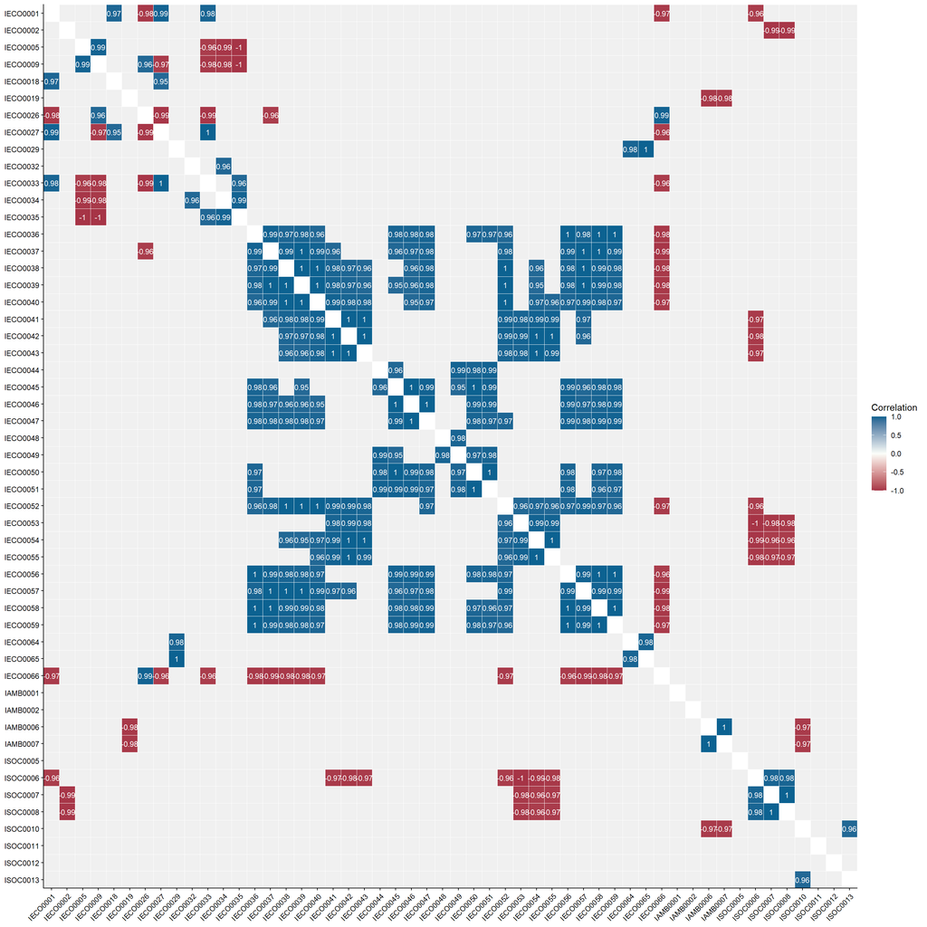

```r
coin_2022 <- purse$coin[[which(purse$Time == 2022)]]

# uso función nativa del paquete COINr para dibujarlo
plot_corr(
  coin_2022,
  dset     = "Normalised",
  grouplev = 3,
  flagging = TRUE,
  cortype  = "pearson"
)
```

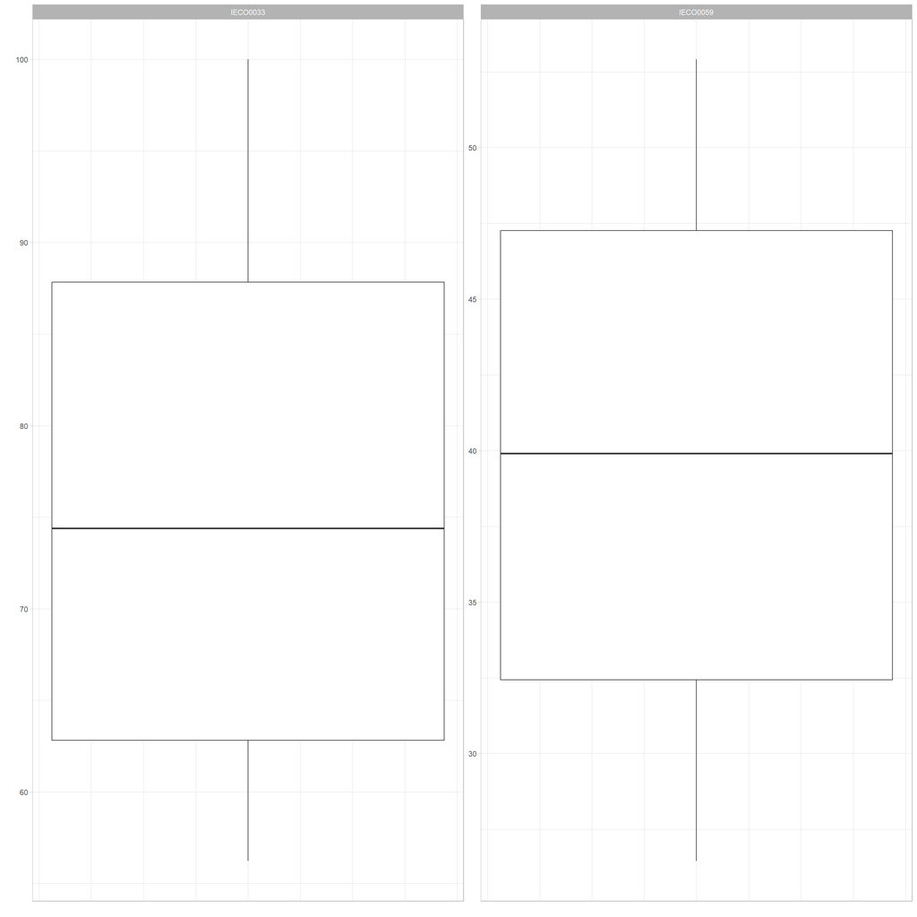

```r
# Ejemplos de distintos gráficos que podemos hacer con la función plot_dist de COINr
plot_dist(coin_2022, iCodes = c("IECO0033","IECO0059"), dset = "Normalised", type="Box", normalise = FALSE)
```

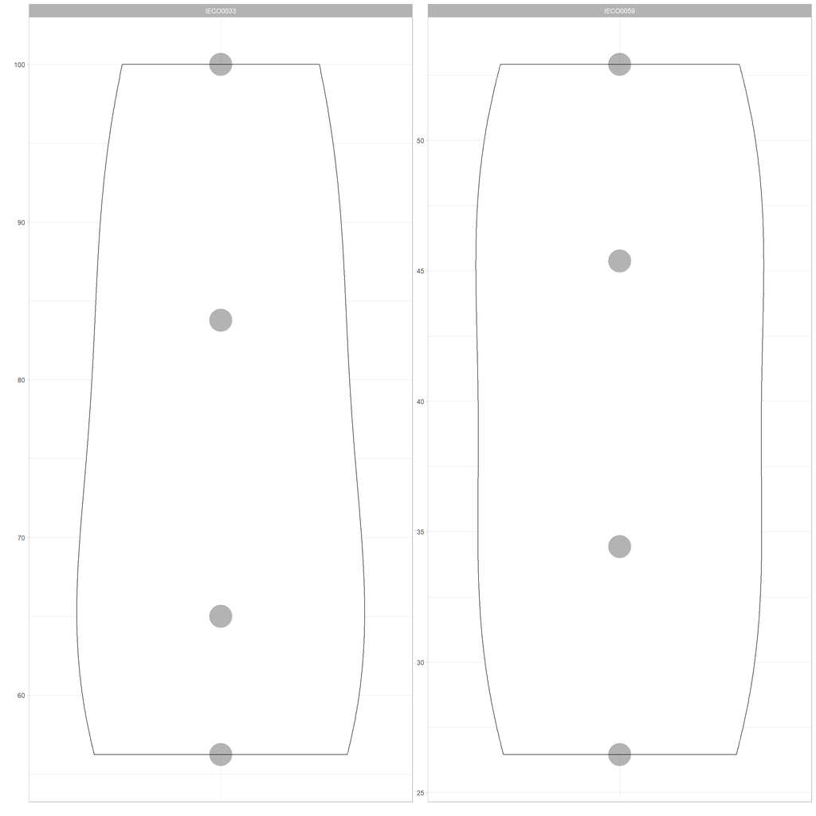

```r
plot_dist(coin_2022, iCodes = c("IECO0033","IECO0059"), dset = "Normalised", type="Violindot", normalise = FALSE)
```

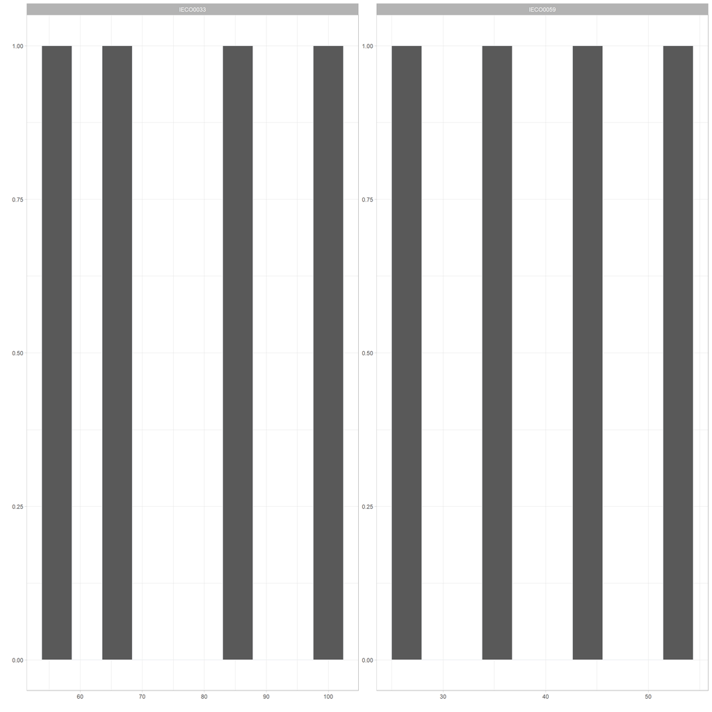

```r
plot_dist(coin_2022, iCodes = c("IECO0033","IECO0059"), dset = "Normalised", type="Histogram", normalise = FALSE)
```

```r
# dataframe de correlaciones en 2022
df_corr_2022 <- get_corr(coin_2022, dset="Normalised", Levels=1, cortype="pearson", make_long=TRUE)

# quiero extraer una lista con las correlaciones más altas
corr_altas_2022 <- df_corr_2022 |>
  filter(Correlation>=0.8, Var1 != Var2, Var1 < Var2) |>
  select(Var1,Var2,Correlation) |>
  arrange(desc(Correlation))

kable(head(corr_altas_2022, 20), digits = 3, caption = "Top 20 Correlaciones más altas")
```

Top 20 Correlaciones más altas

| Var1 | Var2 | Correlation |
| --- | --- | --- |
| IAMB0006 | IAMB0007 | 1.000 |
| ISOC0007 | ISOC0008 | 1.000 |
| IECO0029 | IECO0065 | 1.000 |
| IECO0038 | IECO0039 | 1.000 |
| IECO0039 | IECO0057 | 0.999 |
| IECO0045 | IECO0046 | 0.999 |
| IECO0040 | IECO0052 | 0.999 |
| IECO0050 | IECO0051 | 0.999 |
| IECO0054 | IECO0055 | 0.999 |
| IECO0036 | IECO0059 | 0.999 |
| IECO0058 | IECO0059 | 0.999 |
| IECO0056 | IECO0059 | 0.999 |
| IECO0041 | IECO0042 | 0.999 |
| IECO0037 | IECO0057 | 0.998 |
| IECO0027 | IECO0033 | 0.998 |
| IECO0038 | IECO0057 | 0.998 |
| IECO0042 | IECO0054 | 0.998 |
| IECO0038 | IECO0040 | 0.998 |
| IECO0038 | IECO0052 | 0.998 |
| IECO0056 | IECO0058 | 0.998 |

Conclusiones viendo el gráfico:

Cohesión en la dimensión ECO: bloque densamente correlacionado en los indicadores IECO… (valores de r>0.80). Esto sugiere una alta redundancia informativa que debe ser considerada en la ponderación final.

Trade-offs y conflictos de sostenibilidad: las correlaciones negativas entre algunos indicadores de crecimiento económico y sostenibilidad social/ambiental sugiere la existencia de “conflictos de intereses”. Estos puntos son críticos para el análisis, ya que identifican áreas donde el progreso económico podría estar comprometiendo otros pilares del bienestar.

Validez del enfoque multidimensional: la heterogeneidad de colores en el gráfico y la presencia de amplias zonas de baja correlación confirman que estamos analizando un fenómeno complejo y que un ranking basado únicamente en variables económicas no sería suficiente para reflejar la realidad de la sostenibilidad regional en España.

## Correlaciones por año

```r
anios_disponibles <- sort(unique(purse$Time))

for (a in anios_disponibles) {

  # Extraemos el año
  resultado <- tryCatch({
  coin_anio <- purse$coin[[which(purse$Time == a)]]

  # plot_corr para todos los años

  cat("\n\n### Matriz de Correlación - Año", a, "\n")

  p <- plot_corr(
    coin_anio,
    dset     = "Normalised",
    grouplev = 3,
    flagging  = TRUE,
    cortype  = "pearson",
    text_size = 3
  )
  print(p)

  # tabla de correlaciones altas
  cat("\n\n### Tabla de correlaciones más altas (>0.8) - Año", a, "\n")

  # dataframe de correlaciones
  df_corr_anio <- get_corr(coin_anio, dset="Normalised", Levels=1, cortype="pearson", make_long=TRUE)

  # lista con las correlaciones más altas (>0.8)
  corr_altas_anio <- df_corr_anio |>
    filter(Correlation>=0.8,
           Var1 < Var2) |>
    arrange(desc(Correlation))

  print(knitr::kable(head(corr_altas_anio, n = 10), digits = 3, caption = paste("Top 10 correlaciones generales - Año", a)))

  # correlaciones que nos "descuadran" en el PCA+Varimax (pondríamos los indicadores juntos pero salen separados)
  eco_rc1 <- c("IECO0046","IECO0058","IECO0059")
  eco_rc6 <- c("IECO0044","IECO0045","IECO0047","IECO0056","IECO0057")
  todos_eco <- c(eco_rc1,eco_rc6)

  soc_rc1 <- c("ISOC0013","ISOC0010","ISOC0012")
  soc_rc2 <- c("ISOC0011")
  todos_soc <- c(soc_rc1,soc_rc2)

  # creo mapeo de RCs
    # Creamos un dataframe auxiliar para "etiquetar" cada código
    mapeo_rc <- data.frame(
      Cod = c(eco_rc1, eco_rc6, soc_rc1, soc_rc2),
      RC  = c(rep("RC1", length(eco_rc1)),
              rep("RC6", length(eco_rc6)),
              rep("RC1", length(soc_rc1)),
              rep("RC2", length(soc_rc2)))
    )

    # Función interna para añadir las etiquetas RC a las tablas
    añadir_rc <- function(tabla) {
      tabla |>
        left_join(mapeo_rc, by = c("Var1" = "Cod")) |>
        rename(RC_Var1 = RC) |>
        left_join(mapeo_rc, by = c("Var2" = "Cod")) |>
        rename(RC_Var2 = RC) |>
        # Reordenamos columnas para que sea legible
        select(Var1, RC_Var1, Var2, RC_Var2, Correlation)
    }

  precio_estrellas <- df_corr_anio |>
    filter(Var1 %in% todos_eco, Var2 %in% todos_eco, Var1<Var2) |>
    arrange(desc(Correlation)) |>
    añadir_rc()

  cat("\n\n### Correlaciones dimensión ECO, RC1 y RC6 (precio medio según antelación y estrellas hotel) - Año", a, "\n")
  if(nrow(precio_estrellas) > 0) {
    print(knitr::kable(precio_estrellas, digits = 3, caption = paste("Correlaciones dimensión ECO, RC1 y RC6 (precio medio según antelación y estrellas hotel) - Año", a)))
    leyenda_eco <- iMeta |> filter(iCode %in% unique(c(precio_estrellas$Var1, precio_estrellas$Var2))) |> select(iCode, iName)
      cat("\n**Descripción indicadores:**", paste(leyenda_eco$iCode, leyenda_eco$iName, sep=": ", collapse=" | "), "\n")
  } else {
    cat("\nNo hay correlaciones significativas en este grupo.\n")
  }

  satisfaccion <- df_corr_anio |>
    filter(Var1 %in% todos_soc, Var2 %in% todos_soc, Var1<Var2) |>
    arrange(desc(Correlation))|>
    añadir_rc()

  cat("\n\n### Correlaciones dimensión SOC, RC1 y RC2 (satisfacción hoteles según estrellas) - Año", a, "\n")
  if(nrow(satisfaccion) > 0) {
    print(knitr::kable(satisfaccion, digits = 3, caption = paste("Correlaciones dimensión SOC, RC1 y RC2 (satisfacción hoteles según estrellas) - Año", a)))
    leyenda_soc <- iMeta |> filter(iCode %in% unique(c(satisfaccion$Var1, satisfaccion$Var2))) |> select(iCode, iName)
      cat("\n**Descripción indicadores:**", paste(leyenda_soc$iCode, leyenda_soc$iName, sep=": ", collapse=" | "), "\n")
  } else {
    cat("\nNo hay correlaciones significativas en este grupo.\n")
  }

  }, error = function(e) {
    # Si algo falla (ya sea el gráfico o la tabla), se ejecuta esto y el bucle SIGUE
    cat("\n\n> **AVISO:** No se han podido procesar las correlaciones para el año", a,
        ". Probablemente debido a datos vacíos o falta de varianza.\n")
    message(paste("Error en año", a, ":", e$message)) # Esto sale en la consola de RStudio
  })

  cat("\n---\n")
}
```

### Matriz de Correlación - Año 2019

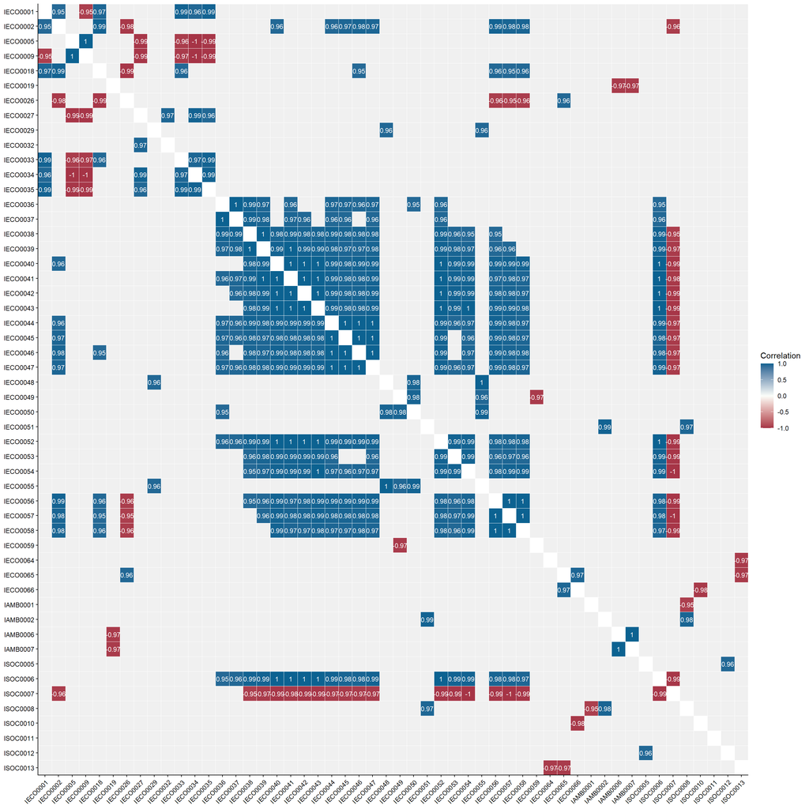

### Tabla de correlaciones más altas (>0.8) - Año 2019

Top 10 correlaciones generales - Año 2019

| Var1 | Var2 | Correlation |
| --- | --- | --- |
| IAMB0006 | IAMB0007 | 1.000 |
| IECO0042 | ISOC0006 | 1.000 |
| IECO0041 | ISOC0006 | 1.000 |
| IECO0044 | IECO0047 | 1.000 |
| IECO0005 | IECO0009 | 1.000 |
| IECO0045 | IECO0046 | 1.000 |
| IECO0040 | IECO0043 | 0.999 |
| IECO0052 | ISOC0006 | 0.999 |
| IECO0042 | IECO0043 | 0.999 |
| IECO0045 | IECO0047 | 0.999 |

### Correlaciones dimensión ECO, RC1 y RC6 (precio medio según antelación y estrellas hotel) - Año 2019

Correlaciones dimensión ECO, RC1 y RC6 (precio medio según antelación y estrellas hotel) - Año 2019

| Var1 | RC_Var1 | Var2 | RC_Var2 | Correlation |
| --- | --- | --- | --- | --- |
| IECO0044 | RC6 | IECO0047 | RC6 | 1.000 |
| IECO0045 | RC6 | IECO0046 | RC1 | 1.000 |
| IECO0045 | RC6 | IECO0047 | RC6 | 0.999 |
| IECO0046 | RC1 | IECO0047 | RC6 | 0.999 |
| IECO0057 | RC6 | IECO0058 | RC1 | 0.999 |
| IECO0056 | RC6 | IECO0057 | RC6 | 0.999 |
| IECO0044 | RC6 | IECO0045 | RC6 | 0.998 |
| IECO0044 | RC6 | IECO0046 | RC1 | 0.998 |
| IECO0056 | RC6 | IECO0058 | RC1 | 0.997 |
| IECO0046 | RC1 | IECO0056 | RC6 | 0.990 |
| IECO0047 | RC6 | IECO0056 | RC6 | 0.988 |
| IECO0045 | RC6 | IECO0056 | RC6 | 0.987 |
| IECO0044 | RC6 | IECO0056 | RC6 | 0.986 |
| IECO0046 | RC1 | IECO0057 | RC6 | 0.984 |
| IECO0047 | RC6 | IECO0057 | RC6 | 0.982 |
| IECO0044 | RC6 | IECO0057 | RC6 | 0.981 |
| IECO0045 | RC6 | IECO0057 | RC6 | 0.979 |
| IECO0046 | RC1 | IECO0058 | RC1 | 0.977 |
| IECO0047 | RC6 | IECO0058 | RC1 | 0.974 |
| IECO0044 | RC6 | IECO0058 | RC1 | 0.972 |
| IECO0045 | RC6 | IECO0058 | RC1 | 0.971 |
| IECO0044 | RC6 | IECO0059 | RC1 | NA |
| IECO0045 | RC6 | IECO0059 | RC1 | NA |
| IECO0046 | RC1 | IECO0059 | RC1 | NA |
| IECO0047 | RC6 | IECO0059 | RC1 | NA |
| IECO0056 | RC6 | IECO0059 | RC1 | NA |
| IECO0057 | RC6 | IECO0059 | RC1 | NA |
| IECO0058 | RC1 | IECO0059 | RC1 | NA |

**Descripción indicadores:** IECO0044: Precio medio para hotel 3 estrellas con 3 meses de antelación con fecha de check-in entre semana | IECO0045: Precio medio para hotel 3 estrellas con 1 mes de antelación con fecha de check-in entre semana | IECO0046: Precio medio para hotel 3 estrellas con 2 semanas de antelación con fecha de check-in entre semana | IECO0047: Precio medio para hotel 3 estrellas con 1 semana de antelación con fecha de check-in entre semana | IECO0056: Precio medio para hotel 3 estrellas con 3 meses de antelación con fecha de check-in en fin de semana | IECO0057: Precio medio para hotel 3 estrellas con 1 mes de antelación con fecha de check-in en fin de semana | IECO0058: Precio medio para hotel 3 estrellas con 2 semanas de antelación con fecha de check-in en fin de semana | IECO0059: Precio medio para hotel 3 estrellas con 1 semana de antelación con fecha de check-in en fin de semana

### Correlaciones dimensión SOC, RC1 y RC2 (satisfacción hoteles según estrellas) - Año 2019

Correlaciones dimensión SOC, RC1 y RC2 (satisfacción hoteles según estrellas) - Año 2019

| Var1 | RC_Var1 | Var2 | RC_Var2 | Correlation |
| --- | --- | --- | --- | --- |
| ISOC0010 | RC1 | ISOC0011 | RC2 | NA |
| ISOC0010 | RC1 | ISOC0012 | RC1 | NA |
| ISOC0011 | RC2 | ISOC0012 | RC1 | NA |
| ISOC0010 | RC1 | ISOC0013 | RC1 | NA |
| ISOC0011 | RC2 | ISOC0013 | RC1 | NA |
| ISOC0012 | RC1 | ISOC0013 | RC1 | NA |

**Descripción indicadores:** ISOC0010: Índice de satisfacción con los hoteles 5 estrellas | ISOC0011: Índice de satisfacción con los hoteles 4 estrellas | ISOC0012: Índice de satisfacción con los hoteles 3 estrellas | ISOC0013: Índice de satisfacción con los alojamientos hoteleros

### Matriz de Correlación - Año 2020

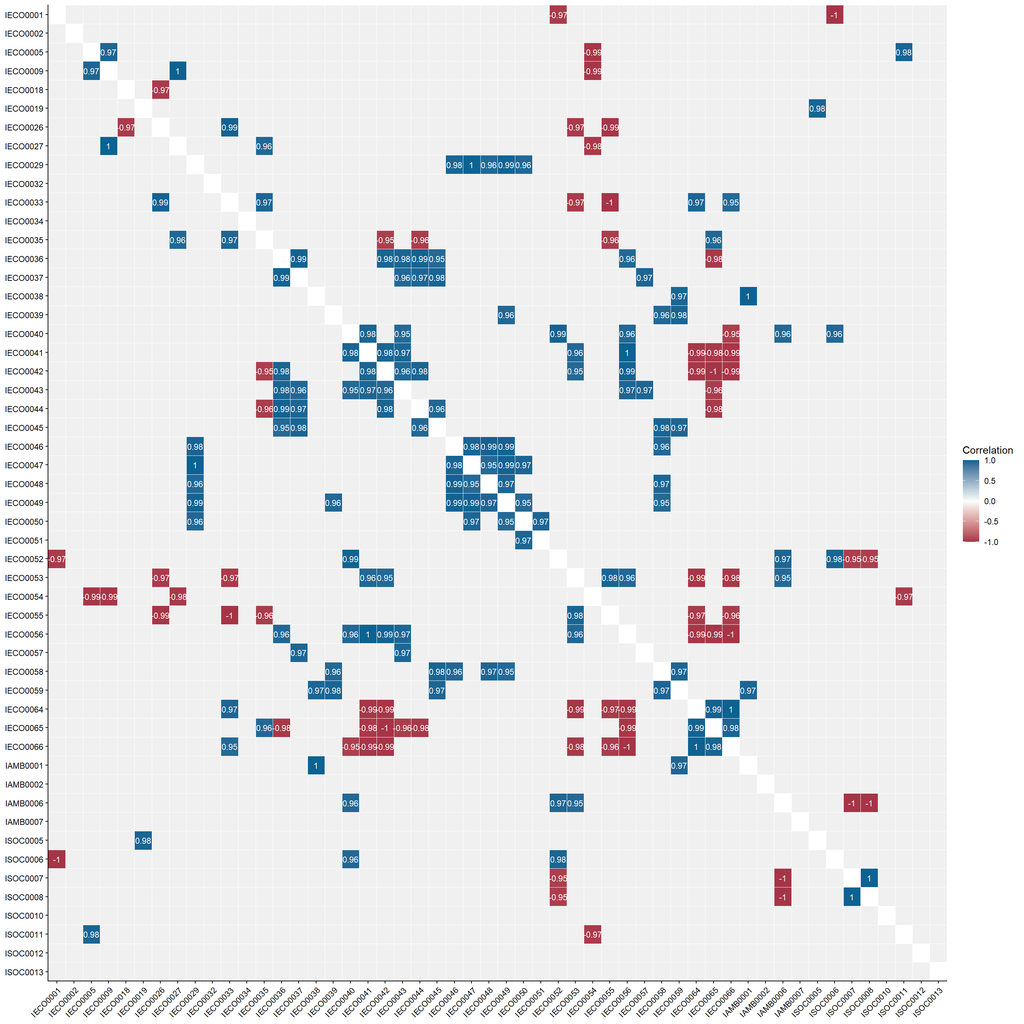

### Tabla de correlaciones más altas (>0.8) - Año 2020

Top 10 correlaciones generales - Año 2020

| Var1 | Var2 | Correlation |
| --- | --- | --- |
| ISOC0007 | ISOC0008 | 1.000 |
| IAMB0001 | IECO0038 | 1.000 |
| IECO0029 | IECO0047 | 0.999 |
| IECO0041 | IECO0056 | 0.998 |
| IECO0064 | IECO0066 | 0.998 |
| IECO0009 | IECO0027 | 0.996 |
| IECO0046 | IECO0048 | 0.993 |
| IECO0046 | IECO0049 | 0.992 |
| IECO0026 | IECO0033 | 0.992 |
| IECO0042 | IECO0056 | 0.991 |

### Correlaciones dimensión ECO, RC1 y RC6 (precio medio según antelación y estrellas hotel) - Año 2020

Correlaciones dimensión ECO, RC1 y RC6 (precio medio según antelación y estrellas hotel) - Año 2020

| Var1 | RC_Var1 | Var2 | RC_Var2 | Correlation |
| --- | --- | --- | --- | --- |
| IECO0045 | RC6 | IECO0058 | RC1 | 0.984 |
| IECO0046 | RC1 | IECO0047 | RC6 | 0.978 |
| IECO0058 | RC1 | IECO0059 | RC1 | 0.975 |
| IECO0045 | RC6 | IECO0059 | RC1 | 0.969 |
| IECO0046 | RC1 | IECO0058 | RC1 | 0.962 |
| IECO0044 | RC6 | IECO0045 | RC6 | 0.961 |
| IECO0044 | RC6 | IECO0046 | RC1 | NA |
| IECO0045 | RC6 | IECO0046 | RC1 | NA |
| IECO0044 | RC6 | IECO0047 | RC6 | NA |
| IECO0045 | RC6 | IECO0047 | RC6 | NA |
| IECO0044 | RC6 | IECO0056 | RC6 | NA |
| IECO0045 | RC6 | IECO0056 | RC6 | NA |
| IECO0046 | RC1 | IECO0056 | RC6 | NA |
| IECO0047 | RC6 | IECO0056 | RC6 | NA |
| IECO0044 | RC6 | IECO0057 | RC6 | NA |
| IECO0045 | RC6 | IECO0057 | RC6 | NA |
| IECO0046 | RC1 | IECO0057 | RC6 | NA |
| IECO0047 | RC6 | IECO0057 | RC6 | NA |
| IECO0056 | RC6 | IECO0057 | RC6 | NA |
| IECO0044 | RC6 | IECO0058 | RC1 | NA |
| IECO0047 | RC6 | IECO0058 | RC1 | NA |
| IECO0056 | RC6 | IECO0058 | RC1 | NA |
| IECO0057 | RC6 | IECO0058 | RC1 | NA |
| IECO0044 | RC6 | IECO0059 | RC1 | NA |
| IECO0046 | RC1 | IECO0059 | RC1 | NA |
| IECO0047 | RC6 | IECO0059 | RC1 | NA |
| IECO0056 | RC6 | IECO0059 | RC1 | NA |
| IECO0057 | RC6 | IECO0059 | RC1 | NA |

**Descripción indicadores:** IECO0044: Precio medio para hotel 3 estrellas con 3 meses de antelación con fecha de check-in entre semana | IECO0045: Precio medio para hotel 3 estrellas con 1 mes de antelación con fecha de check-in entre semana | IECO0046: Precio medio para hotel 3 estrellas con 2 semanas de antelación con fecha de check-in entre semana | IECO0047: Precio medio para hotel 3 estrellas con 1 semana de antelación con fecha de check-in entre semana | IECO0056: Precio medio para hotel 3 estrellas con 3 meses de antelación con fecha de check-in en fin de semana | IECO0057: Precio medio para hotel 3 estrellas con 1 mes de antelación con fecha de check-in en fin de semana | IECO0058: Precio medio para hotel 3 estrellas con 2 semanas de antelación con fecha de check-in en fin de semana | IECO0059: Precio medio para hotel 3 estrellas con 1 semana de antelación con fecha de check-in en fin de semana

### Correlaciones dimensión SOC, RC1 y RC2 (satisfacción hoteles según estrellas) - Año 2020

Correlaciones dimensión SOC, RC1 y RC2 (satisfacción hoteles según estrellas) - Año 2020

| Var1 | RC_Var1 | Var2 | RC_Var2 | Correlation |
| --- | --- | --- | --- | --- |
| ISOC0010 | RC1 | ISOC0011 | RC2 | NA |
| ISOC0010 | RC1 | ISOC0012 | RC1 | NA |
| ISOC0011 | RC2 | ISOC0012 | RC1 | NA |
| ISOC0010 | RC1 | ISOC0013 | RC1 | NA |
| ISOC0011 | RC2 | ISOC0013 | RC1 | NA |
| ISOC0012 | RC1 | ISOC0013 | RC1 | NA |

**Descripción indicadores:** ISOC0010: Índice de satisfacción con los hoteles 5 estrellas | ISOC0011: Índice de satisfacción con los hoteles 4 estrellas | ISOC0012: Índice de satisfacción con los hoteles 3 estrellas | ISOC0013: Índice de satisfacción con los alojamientos hoteleros

### Matriz de Correlación - Año 2021

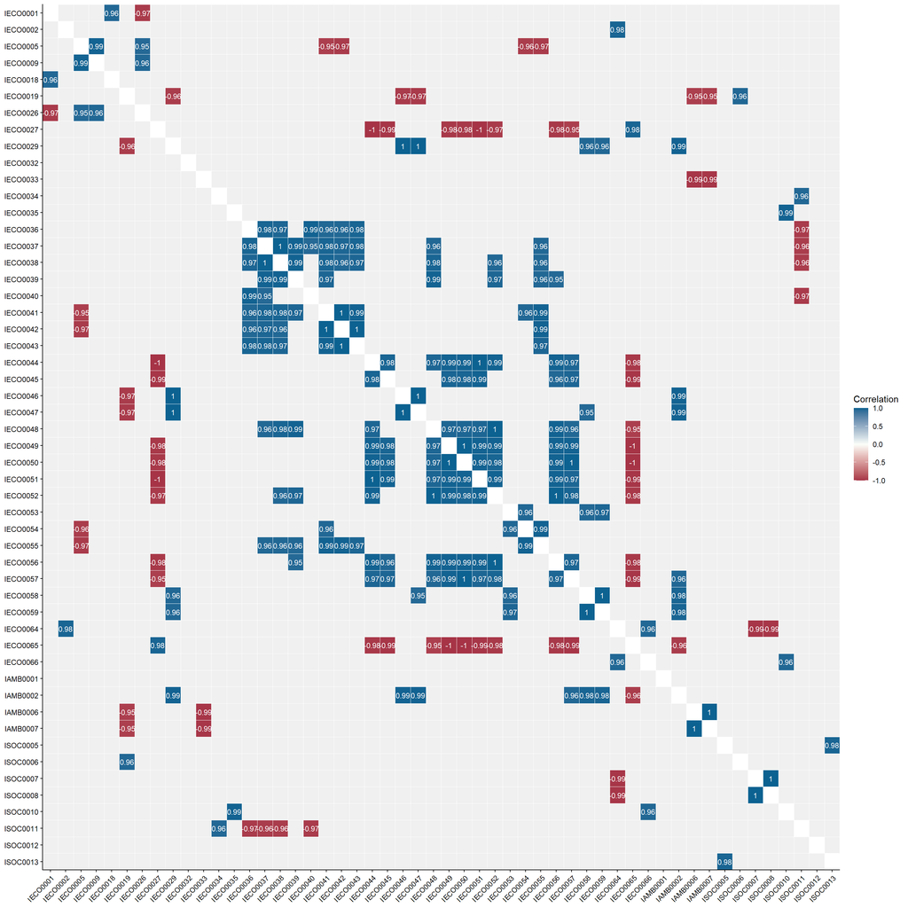

### Tabla de correlaciones más altas (>0.8) - Año 2021

Top 10 correlaciones generales - Año 2021

| Var1 | Var2 | Correlation |
| --- | --- | --- |
| IAMB0006 | IAMB0007 | 1.000 |
| ISOC0007 | ISOC0008 | 1.000 |
| IECO0058 | IECO0059 | 1.000 |
| IECO0049 | IECO0050 | 1.000 |
| IECO0044 | IECO0051 | 1.000 |
| IECO0046 | IECO0047 | 0.999 |
| IECO0029 | IECO0047 | 0.999 |
| IECO0029 | IECO0046 | 0.998 |
| IECO0052 | IECO0056 | 0.998 |
| IECO0037 | IECO0038 | 0.997 |

### Correlaciones dimensión ECO, RC1 y RC6 (precio medio según antelación y estrellas hotel) - Año 2021

Correlaciones dimensión ECO, RC1 y RC6 (precio medio según antelación y estrellas hotel) - Año 2021

| Var1 | RC_Var1 | Var2 | RC_Var2 | Correlation |
| --- | --- | --- | --- | --- |
| IECO0058 | RC1 | IECO0059 | RC1 | 1.000 |
| IECO0046 | RC1 | IECO0047 | RC6 | 0.999 |
| IECO0044 | RC6 | IECO0056 | RC6 | 0.995 |
| IECO0044 | RC6 | IECO0045 | RC6 | 0.983 |
| IECO0056 | RC6 | IECO0057 | RC6 | 0.974 |
| IECO0044 | RC6 | IECO0057 | RC6 | 0.968 |
| IECO0045 | RC6 | IECO0057 | RC6 | 0.966 |
| IECO0045 | RC6 | IECO0056 | RC6 | 0.964 |
| IECO0047 | RC6 | IECO0058 | RC1 | 0.952 |
| IECO0044 | RC6 | IECO0046 | RC1 | NA |
| IECO0045 | RC6 | IECO0046 | RC1 | NA |
| IECO0044 | RC6 | IECO0047 | RC6 | NA |
| IECO0045 | RC6 | IECO0047 | RC6 | NA |
| IECO0046 | RC1 | IECO0056 | RC6 | NA |
| IECO0047 | RC6 | IECO0056 | RC6 | NA |
| IECO0046 | RC1 | IECO0057 | RC6 | NA |
| IECO0047 | RC6 | IECO0057 | RC6 | NA |
| IECO0044 | RC6 | IECO0058 | RC1 | NA |
| IECO0045 | RC6 | IECO0058 | RC1 | NA |
| IECO0046 | RC1 | IECO0058 | RC1 | NA |
| IECO0056 | RC6 | IECO0058 | RC1 | NA |
| IECO0057 | RC6 | IECO0058 | RC1 | NA |
| IECO0044 | RC6 | IECO0059 | RC1 | NA |
| IECO0045 | RC6 | IECO0059 | RC1 | NA |
| IECO0046 | RC1 | IECO0059 | RC1 | NA |
| IECO0047 | RC6 | IECO0059 | RC1 | NA |
| IECO0056 | RC6 | IECO0059 | RC1 | NA |
| IECO0057 | RC6 | IECO0059 | RC1 | NA |

**Descripción indicadores:** IECO0044: Precio medio para hotel 3 estrellas con 3 meses de antelación con fecha de check-in entre semana | IECO0045: Precio medio para hotel 3 estrellas con 1 mes de antelación con fecha de check-in entre semana | IECO0046: Precio medio para hotel 3 estrellas con 2 semanas de antelación con fecha de check-in entre semana | IECO0047: Precio medio para hotel 3 estrellas con 1 semana de antelación con fecha de check-in entre semana | IECO0056: Precio medio para hotel 3 estrellas con 3 meses de antelación con fecha de check-in en fin de semana | IECO0057: Precio medio para hotel 3 estrellas con 1 mes de antelación con fecha de check-in en fin de semana | IECO0058: Precio medio para hotel 3 estrellas con 2 semanas de antelación con fecha de check-in en fin de semana | IECO0059: Precio medio para hotel 3 estrellas con 1 semana de antelación con fecha de check-in en fin de semana

### Correlaciones dimensión SOC, RC1 y RC2 (satisfacción hoteles según estrellas) - Año 2021

Correlaciones dimensión SOC, RC1 y RC2 (satisfacción hoteles según estrellas) - Año 2021

| Var1 | RC_Var1 | Var2 | RC_Var2 | Correlation |
| --- | --- | --- | --- | --- |
| ISOC0010 | RC1 | ISOC0011 | RC2 | NA |
| ISOC0010 | RC1 | ISOC0012 | RC1 | NA |
| ISOC0011 | RC2 | ISOC0012 | RC1 | NA |
| ISOC0010 | RC1 | ISOC0013 | RC1 | NA |
| ISOC0011 | RC2 | ISOC0013 | RC1 | NA |
| ISOC0012 | RC1 | ISOC0013 | RC1 | NA |

**Descripción indicadores:** ISOC0010: Índice de satisfacción con los hoteles 5 estrellas | ISOC0011: Índice de satisfacción con los hoteles 4 estrellas | ISOC0012: Índice de satisfacción con los hoteles 3 estrellas | ISOC0013: Índice de satisfacción con los alojamientos hoteleros

### Matriz de Correlación - Año 2022

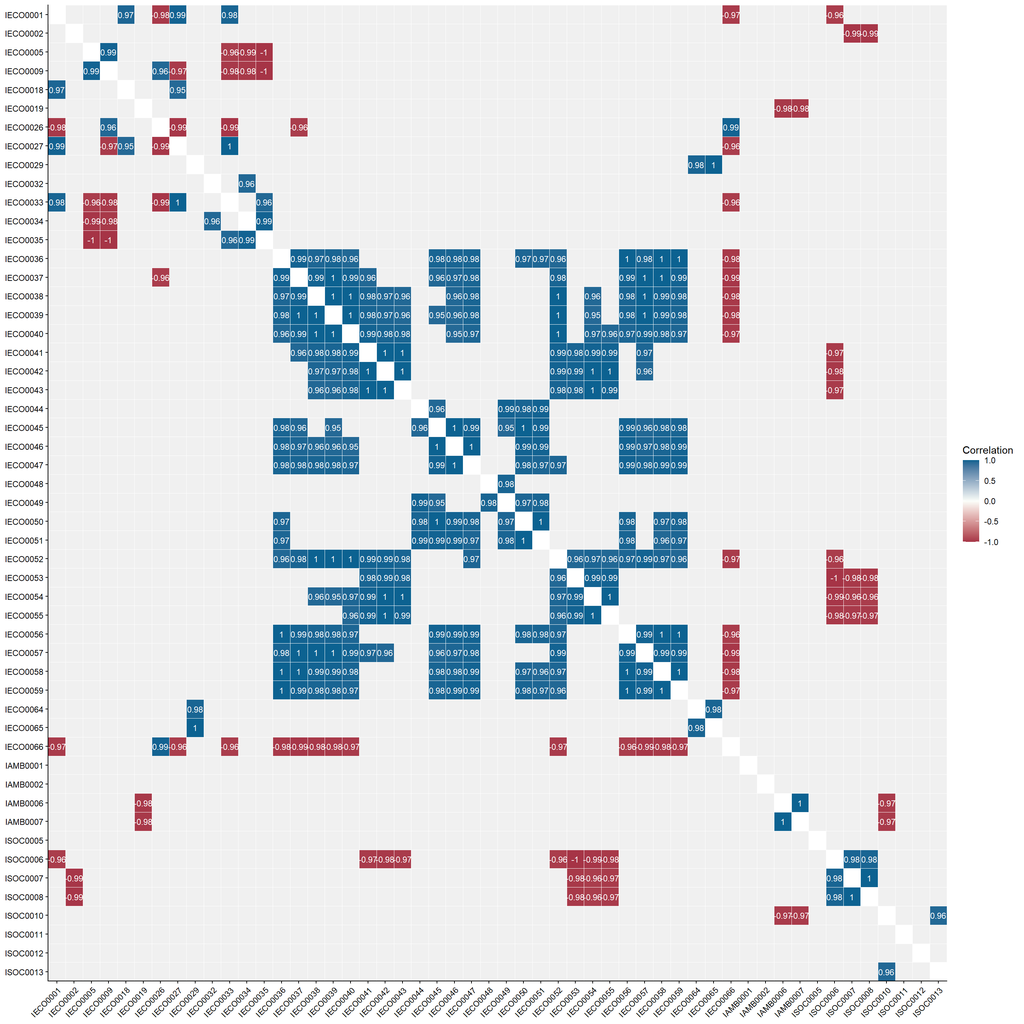

### Tabla de correlaciones más altas (>0.8) - Año 2022

Top 10 correlaciones generales - Año 2022

| Var1 | Var2 | Correlation |
| --- | --- | --- |
| IAMB0006 | IAMB0007 | 1.000 |
| ISOC0007 | ISOC0008 | 1.000 |
| IECO0029 | IECO0065 | 1.000 |
| IECO0038 | IECO0039 | 1.000 |
| IECO0039 | IECO0057 | 0.999 |
| IECO0045 | IECO0046 | 0.999 |
| IECO0040 | IECO0052 | 0.999 |
| IECO0050 | IECO0051 | 0.999 |
| IECO0054 | IECO0055 | 0.999 |
| IECO0036 | IECO0059 | 0.999 |

### Correlaciones dimensión ECO, RC1 y RC6 (precio medio según antelación y estrellas hotel) - Año 2022

Correlaciones dimensión ECO, RC1 y RC6 (precio medio según antelación y estrellas hotel) - Año 2022

| Var1 | RC_Var1 | Var2 | RC_Var2 | Correlation |
| --- | --- | --- | --- | --- |
| IECO0045 | RC6 | IECO0046 | RC1 | 0.999 |
| IECO0058 | RC1 | IECO0059 | RC1 | 0.999 |
| IECO0056 | RC6 | IECO0059 | RC1 | 0.999 |
| IECO0056 | RC6 | IECO0058 | RC1 | 0.998 |
| IECO0046 | RC1 | IECO0047 | RC6 | 0.996 |
| IECO0057 | RC6 | IECO0058 | RC1 | 0.993 |
| IECO0046 | RC1 | IECO0056 | RC6 | 0.993 |
| IECO0047 | RC6 | IECO0056 | RC6 | 0.993 |
| IECO0045 | RC6 | IECO0047 | RC6 | 0.992 |
| IECO0045 | RC6 | IECO0056 | RC6 | 0.990 |
| IECO0057 | RC6 | IECO0059 | RC1 | 0.988 |
| IECO0056 | RC6 | IECO0057 | RC6 | 0.987 |
| IECO0046 | RC1 | IECO0059 | RC1 | 0.987 |
| IECO0047 | RC6 | IECO0058 | RC1 | 0.986 |
| IECO0047 | RC6 | IECO0059 | RC1 | 0.985 |
| IECO0045 | RC6 | IECO0059 | RC1 | 0.984 |
| IECO0046 | RC1 | IECO0058 | RC1 | 0.984 |
| IECO0045 | RC6 | IECO0058 | RC1 | 0.979 |
| IECO0047 | RC6 | IECO0057 | RC6 | 0.979 |
| IECO0046 | RC1 | IECO0057 | RC6 | 0.966 |
| IECO0044 | RC6 | IECO0045 | RC6 | 0.960 |
| IECO0045 | RC6 | IECO0057 | RC6 | 0.958 |
| IECO0044 | RC6 | IECO0046 | RC1 | NA |
| IECO0044 | RC6 | IECO0047 | RC6 | NA |
| IECO0044 | RC6 | IECO0056 | RC6 | NA |
| IECO0044 | RC6 | IECO0057 | RC6 | NA |
| IECO0044 | RC6 | IECO0058 | RC1 | NA |
| IECO0044 | RC6 | IECO0059 | RC1 | NA |

**Descripción indicadores:** IECO0044: Precio medio para hotel 3 estrellas con 3 meses de antelación con fecha de check-in entre semana | IECO0045: Precio medio para hotel 3 estrellas con 1 mes de antelación con fecha de check-in entre semana | IECO0046: Precio medio para hotel 3 estrellas con 2 semanas de antelación con fecha de check-in entre semana | IECO0047: Precio medio para hotel 3 estrellas con 1 semana de antelación con fecha de check-in entre semana | IECO0056: Precio medio para hotel 3 estrellas con 3 meses de antelación con fecha de check-in en fin de semana | IECO0057: Precio medio para hotel 3 estrellas con 1 mes de antelación con fecha de check-in en fin de semana | IECO0058: Precio medio para hotel 3 estrellas con 2 semanas de antelación con fecha de check-in en fin de semana | IECO0059: Precio medio para hotel 3 estrellas con 1 semana de antelación con fecha de check-in en fin de semana

### Correlaciones dimensión SOC, RC1 y RC2 (satisfacción hoteles según estrellas) - Año 2022

Correlaciones dimensión SOC, RC1 y RC2 (satisfacción hoteles según estrellas) - Año 2022

| Var1 | RC_Var1 | Var2 | RC_Var2 | Correlation |
| --- | --- | --- | --- | --- |
| ISOC0010 | RC1 | ISOC0013 | RC1 | 0.96 |
| ISOC0010 | RC1 | ISOC0011 | RC2 | NA |
| ISOC0010 | RC1 | ISOC0012 | RC1 | NA |
| ISOC0011 | RC2 | ISOC0012 | RC1 | NA |
| ISOC0011 | RC2 | ISOC0013 | RC1 | NA |
| ISOC0012 | RC1 | ISOC0013 | RC1 | NA |

**Descripción indicadores:** ISOC0010: Índice de satisfacción con los hoteles 5 estrellas | ISOC0011: Índice de satisfacción con los hoteles 4 estrellas | ISOC0012: Índice de satisfacción con los hoteles 3 estrellas | ISOC0013: Índice de satisfacción con los alojamientos hoteleros

### Matriz de Correlación - Año 2023

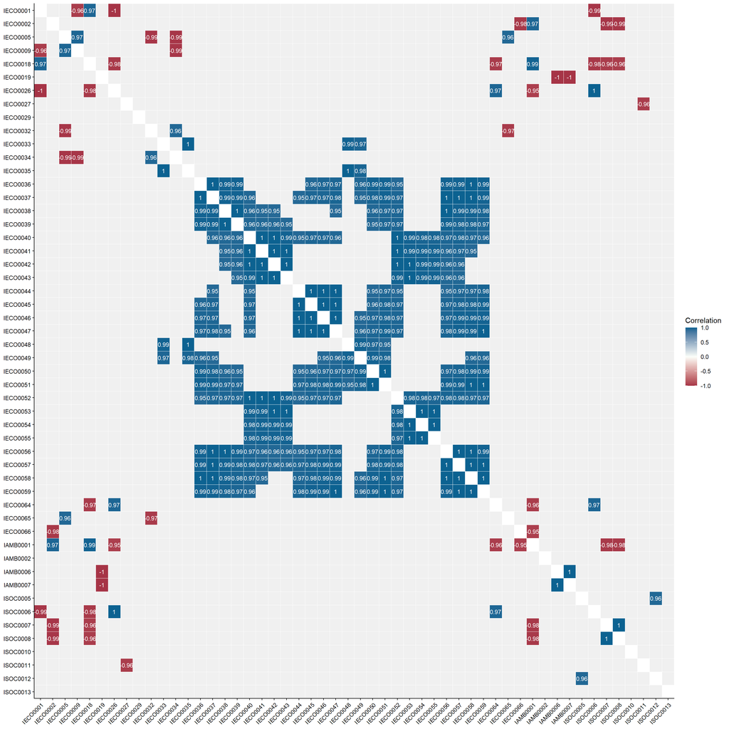

### Tabla de correlaciones más altas (>0.8) - Año 2023

Top 10 correlaciones generales - Año 2023

| Var1 | Var2 | Correlation |
| --- | --- | --- |
| IAMB0006 | IAMB0007 | 1.000 |
| ISOC0007 | ISOC0008 | 1.000 |
| IECO0041 | IECO0042 | 1.000 |
| IECO0054 | IECO0055 | 1.000 |
| IECO0045 | IECO0046 | 1.000 |
| IECO0046 | IECO0047 | 1.000 |
| IECO0042 | IECO0043 | 1.000 |
| IECO0040 | IECO0052 | 1.000 |
| IECO0038 | IECO0039 | 0.999 |
| IECO0041 | IECO0043 | 0.999 |

### Correlaciones dimensión ECO, RC1 y RC6 (precio medio según antelación y estrellas hotel) - Año 2023

Correlaciones dimensión ECO, RC1 y RC6 (precio medio según antelación y estrellas hotel) - Año 2023

| Var1 | RC_Var1 | Var2 | RC_Var2 | Correlation |
| --- | --- | --- | --- | --- |
| IECO0045 | RC6 | IECO0046 | RC1 | 1.000 |
| IECO0046 | RC1 | IECO0047 | RC6 | 1.000 |
| IECO0057 | RC6 | IECO0058 | RC1 | 0.999 |
| IECO0045 | RC6 | IECO0047 | RC6 | 0.999 |
| IECO0058 | RC1 | IECO0059 | RC1 | 0.999 |
| IECO0044 | RC6 | IECO0045 | RC6 | 0.998 |
| IECO0056 | RC6 | IECO0057 | RC6 | 0.998 |
| IECO0044 | RC6 | IECO0046 | RC1 | 0.997 |
| IECO0057 | RC6 | IECO0059 | RC1 | 0.997 |
| IECO0056 | RC6 | IECO0058 | RC1 | 0.997 |
| IECO0044 | RC6 | IECO0047 | RC6 | 0.996 |
| IECO0047 | RC6 | IECO0059 | RC1 | 0.995 |
| IECO0046 | RC1 | IECO0059 | RC1 | 0.993 |
| IECO0056 | RC6 | IECO0059 | RC1 | 0.992 |
| IECO0045 | RC6 | IECO0059 | RC1 | 0.990 |
| IECO0047 | RC6 | IECO0057 | RC6 | 0.989 |
| IECO0047 | RC6 | IECO0058 | RC1 | 0.989 |
| IECO0046 | RC1 | IECO0057 | RC6 | 0.987 |
| IECO0046 | RC1 | IECO0058 | RC1 | 0.986 |
| IECO0045 | RC6 | IECO0057 | RC6 | 0.983 |
| IECO0045 | RC6 | IECO0058 | RC1 | 0.982 |
| IECO0044 | RC6 | IECO0059 | RC1 | 0.982 |
| IECO0047 | RC6 | IECO0056 | RC6 | 0.977 |
| IECO0046 | RC1 | IECO0056 | RC6 | 0.973 |
| IECO0044 | RC6 | IECO0057 | RC6 | 0.972 |
| IECO0044 | RC6 | IECO0058 | RC1 | 0.971 |
| IECO0045 | RC6 | IECO0056 | RC6 | 0.969 |
| IECO0044 | RC6 | IECO0056 | RC6 | 0.954 |

**Descripción indicadores:** IECO0044: Precio medio para hotel 3 estrellas con 3 meses de antelación con fecha de check-in entre semana | IECO0045: Precio medio para hotel 3 estrellas con 1 mes de antelación con fecha de check-in entre semana | IECO0046: Precio medio para hotel 3 estrellas con 2 semanas de antelación con fecha de check-in entre semana | IECO0047: Precio medio para hotel 3 estrellas con 1 semana de antelación con fecha de check-in entre semana | IECO0056: Precio medio para hotel 3 estrellas con 3 meses de antelación con fecha de check-in en fin de semana | IECO0057: Precio medio para hotel 3 estrellas con 1 mes de antelación con fecha de check-in en fin de semana | IECO0058: Precio medio para hotel 3 estrellas con 2 semanas de antelación con fecha de check-in en fin de semana | IECO0059: Precio medio para hotel 3 estrellas con 1 semana de antelación con fecha de check-in en fin de semana

### Correlaciones dimensión SOC, RC1 y RC2 (satisfacción hoteles según estrellas) - Año 2023

Correlaciones dimensión SOC, RC1 y RC2 (satisfacción hoteles según estrellas) - Año 2023

| Var1 | RC_Var1 | Var2 | RC_Var2 | Correlation |
| --- | --- | --- | --- | --- |
| ISOC0010 | RC1 | ISOC0011 | RC2 | NA |
| ISOC0010 | RC1 | ISOC0012 | RC1 | NA |
| ISOC0011 | RC2 | ISOC0012 | RC1 | NA |
| ISOC0010 | RC1 | ISOC0013 | RC1 | NA |
| ISOC0011 | RC2 | ISOC0013 | RC1 | NA |
| ISOC0012 | RC1 | ISOC0013 | RC1 | NA |

**Descripción indicadores:** ISOC0010: Índice de satisfacción con los hoteles 5 estrellas | ISOC0011: Índice de satisfacción con los hoteles 4 estrellas | ISOC0012: Índice de satisfacción con los hoteles 3 estrellas | ISOC0013: Índice de satisfacción con los alojamientos hoteleros

### Matriz de Correlación - Año 2024

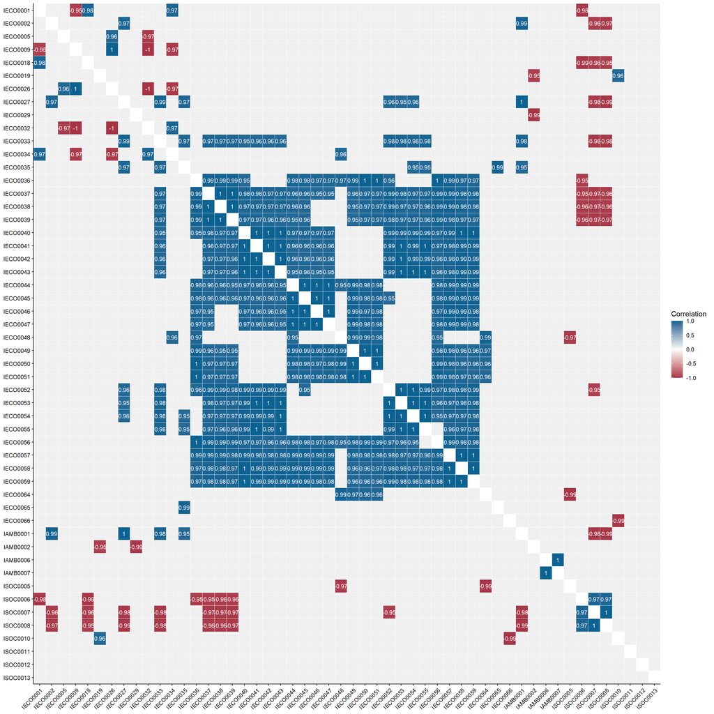

### Tabla de correlaciones más altas (>0.8) - Año 2024

Top 10 correlaciones generales - Año 2024

| Var1 | Var2 | Correlation |
| --- | --- | --- |
| IAMB0006 | IAMB0007 | 1 |
| IECO0046 | IECO0047 | 1 |
| IECO0041 | IECO0042 | 1 |
| IECO0050 | IECO0051 | 1 |
| IECO0041 | IECO0043 | 1 |
| IECO0053 | IECO0054 | 1 |
| IECO0058 | IECO0059 | 1 |
| IECO0044 | IECO0045 | 1 |
| IECO0038 | IECO0039 | 1 |
| IECO0042 | IECO0043 | 1 |

### Correlaciones dimensión ECO, RC1 y RC6 (precio medio según antelación y estrellas hotel) - Año 2024

Correlaciones dimensión ECO, RC1 y RC6 (precio medio según antelación y estrellas hotel) - Año 2024

| Var1 | RC_Var1 | Var2 | RC_Var2 | Correlation |
| --- | --- | --- | --- | --- |
| IECO0046 | RC1 | IECO0047 | RC6 | 1.000 |
| IECO0058 | RC1 | IECO0059 | RC1 | 1.000 |
| IECO0044 | RC6 | IECO0045 | RC6 | 1.000 |
| IECO0044 | RC6 | IECO0047 | RC6 | 1.000 |
| IECO0045 | RC6 | IECO0047 | RC6 | 0.999 |
| IECO0044 | RC6 | IECO0046 | RC1 | 0.999 |
| IECO0045 | RC6 | IECO0046 | RC1 | 0.999 |
| IECO0057 | RC6 | IECO0058 | RC1 | 0.997 |
| IECO0057 | RC6 | IECO0059 | RC1 | 0.997 |
| IECO0056 | RC6 | IECO0057 | RC6 | 0.994 |
| IECO0045 | RC6 | IECO0057 | RC6 | 0.992 |
| IECO0045 | RC6 | IECO0058 | RC1 | 0.991 |
| IECO0044 | RC6 | IECO0057 | RC6 | 0.990 |
| IECO0045 | RC6 | IECO0059 | RC1 | 0.988 |
| IECO0044 | RC6 | IECO0058 | RC1 | 0.988 |
| IECO0047 | RC6 | IECO0057 | RC6 | 0.988 |
| IECO0047 | RC6 | IECO0058 | RC1 | 0.987 |
| IECO0046 | RC1 | IECO0057 | RC6 | 0.987 |
| IECO0046 | RC1 | IECO0058 | RC1 | 0.987 |
| IECO0044 | RC6 | IECO0059 | RC1 | 0.985 |
| IECO0056 | RC6 | IECO0059 | RC1 | 0.984 |
| IECO0056 | RC6 | IECO0058 | RC1 | 0.984 |
| IECO0047 | RC6 | IECO0059 | RC1 | 0.984 |
| IECO0046 | RC1 | IECO0059 | RC1 | 0.984 |
| IECO0045 | RC6 | IECO0056 | RC6 | 0.982 |
| IECO0044 | RC6 | IECO0056 | RC6 | 0.982 |
| IECO0047 | RC6 | IECO0056 | RC6 | 0.976 |
| IECO0046 | RC1 | IECO0056 | RC6 | 0.975 |

**Descripción indicadores:** IECO0044: Precio medio para hotel 3 estrellas con 3 meses de antelación con fecha de check-in entre semana | IECO0045: Precio medio para hotel 3 estrellas con 1 mes de antelación con fecha de check-in entre semana | IECO0046: Precio medio para hotel 3 estrellas con 2 semanas de antelación con fecha de check-in entre semana | IECO0047: Precio medio para hotel 3 estrellas con 1 semana de antelación con fecha de check-in entre semana | IECO0056: Precio medio para hotel 3 estrellas con 3 meses de antelación con fecha de check-in en fin de semana | IECO0057: Precio medio para hotel 3 estrellas con 1 mes de antelación con fecha de check-in en fin de semana | IECO0058: Precio medio para hotel 3 estrellas con 2 semanas de antelación con fecha de check-in en fin de semana | IECO0059: Precio medio para hotel 3 estrellas con 1 semana de antelación con fecha de check-in en fin de semana

### Correlaciones dimensión SOC, RC1 y RC2 (satisfacción hoteles según estrellas) - Año 2024

Correlaciones dimensión SOC, RC1 y RC2 (satisfacción hoteles según estrellas) - Año 2024

| Var1 | RC_Var1 | Var2 | RC_Var2 | Correlation |
| --- | --- | --- | --- | --- |
| ISOC0010 | RC1 | ISOC0011 | RC2 | NA |
| ISOC0010 | RC1 | ISOC0012 | RC1 | NA |
| ISOC0011 | RC2 | ISOC0012 | RC1 | NA |
| ISOC0010 | RC1 | ISOC0013 | RC1 | NA |
| ISOC0011 | RC2 | ISOC0013 | RC1 | NA |
| ISOC0012 | RC1 | ISOC0013 | RC1 | NA |

**Descripción indicadores:** ISOC0010: Índice de satisfacción con los hoteles 5 estrellas | ISOC0011: Índice de satisfacción con los hoteles 4 estrellas | ISOC0012: Índice de satisfacción con los hoteles 3 estrellas | ISOC0013: Índice de satisfacción con los alojamientos hoteleros

## Validación de idoneidad del PCA panel completo

```r
# Usamos el df que ya creamos en el bloque anterior
# Test de Bartlett
bartlett_test <- psych::cortest.bartlett(cor(df_norm_todos, use = "pairwise.complete.obs"),
                                        n = nrow(df_norm_todos))

# Test KMO
kmo_test <- psych::KMO(df_norm_todos)
```

```
Error in solve.default(r) :
  sistema es computacionalmente singular: número de condición recíproco = 7.51444e-20
```

```r
# Imprimimos resultados con un formato limpio
cat("--- TEST DE ESFERICIDAD DE BARTLETT ---\n")
```

```
--- TEST DE ESFERICIDAD DE BARTLETT ---
```

```r
cat("Chi-cuadrado:", bartlett_test$chisq, "\n")
```

```
Chi-cuadrado: Inf
```

```r
cat("P-valor:", bartlett_test$p.value, "\n\n")
```

```
P-valor: 0
```

```r
cat("--- TEST KMO (Kaiser-Meyer-Olkin) ---\n")
```

```
--- TEST KMO (Kaiser-Meyer-Olkin) ---
```

```r
cat("MSA Global:", round(kmo_test$MSAi, 3), "\n")
```

```
MSA Global: 0.5 0.5 0.5 0.5 0.5 0.5 0.5 0.5 0.5 0.5 0.5 0.5 0.5 0.5 0.5 0.5 0.5 0.5 0.5 0.5 0.5 0.5 0.5 0.5 0.5 0.5 0.5 0.5 0.5 0.5 0.5 0.5 0.5 0.5 0.5 0.5 0.5 0.5 0.5 0.5 0.5 0.5 0.5 0.5 0.5 0.5 0.5 0.5 0.5 0.5 0.5 0.5
```

## Validación idoneidad PCA por dimensión

```r
# 1. Definimos las dimensiones según los prefijos de tus indicadores
dimensiones <- list(
  Economica = grep("^IECO", colnames(df_norm_todos), value = TRUE),
  Social    = grep("^ISOC", colnames(df_norm_todos), value = TRUE),
  Ambiental = grep("^IAMB", colnames(df_norm_todos), value = TRUE)
)

# 2. Función para ejecutar los tests de forma segura
test_pca_dim <- function(data, cols, nombre) {
  cat("\n", paste(rep("-", 20), collapse = ""), "\n")
  cat(" ANALIZANDO DIMENSIÓN:", nombre, "\n")
  cat(paste(rep("-", 20), collapse = ""), "\n")

  df_sub <- data[, cols]

  # Bartlett
  # Usamos tryCatch porque si la matriz es singular (det=0), bartlett falla
  tryCatch({
    b_test <- psych::cortest.bartlett(cor(df_sub, use = "pairwise.complete.obs"), n = nrow(df_sub))
    cat(paste0("Bartlett p-value: ", format.pval(b_test$p.value, digits = 3), "\n"))
  }, error = function(e) cat("Bartlett: Error (Matriz singular/Colinealidad extrema)\n"))

  # KMO
  tryCatch({
    k_test <- psych::KMO(df_sub)
    cat(paste0("KMO Global (MSA): ", round(k_test$MSA, 3), "\n"))

    # Interpretación del KMO
    msa <- k_test$MSA
    valoracion <- cut(msa,
                      breaks = c(0, 0.5, 0.6, 0.7, 0.8, 0.9, 1),
                      labels = c("Inaceptable", "Miserable", "Mediocre", "Bueno", "Muy Bueno", "Excelente"))
    cat(paste0("Valoración KMO: ", valoracion, "\n"))

  }, error = function(e) cat("KMO: Error (No se puede calcular por redundancia extrema)\n"))
}

# 3. Ejecutar para cada dimensión
invisible(lapply(names(dimensiones), function(d) test_pca_dim(df_norm_todos, dimensiones[[d]], d)))
```

```
 --------------------
 ANALIZANDO DIMENSIÓN: Economica
--------------------
Bartlett p-value: <2e-16
Error in solve.default(r) :
  sistema es computacionalmente singular: número de condición recíproco = 4.05276e-21
```

```
KMO Global (MSA): 0.5
Valoración KMO: Inaceptable

 --------------------
 ANALIZANDO DIMENSIÓN: Social
--------------------
Bartlett p-value: <2e-16
KMO Global (MSA): 0.558
Valoración KMO: Miserable

 --------------------
 ANALIZANDO DIMENSIÓN: Ambiental
--------------------
Bartlett p-value: 2.62e-08
KMO Global (MSA): 0.667
Valoración KMO: Mediocre
```

ECO: colinealidad casi perfecta (recordar que tenemos 92 pares de indicadores con correlación>0.95). No usar PCA aquí. Usar EW. Como los indicadores se mueven igual, el peso que les demos no cambiará mucho el resultado, pero el método igualitario es mucho más estable y fácil de explicar.

SOC: matemáticamente el PCA es posible, pero “miserable” según la escala de Kaiser. Significa que los indicadores sociales están relacionados, pero de forma débil o con mucho “ruido”. No hay una estructura subyacente única que los una a todos con fuerza. Podemos usar PCA si queremos automatizar los pesos, pero hay que avisar que la estructura es débil.

AMB: hay estructura suficiente para justificar un PCA.

## PCA y clustering para todo el panel

Análisis exploratorio. Hacemos PCA sobre el panel completo apilado (todas las CCAA x tods los años) para entender la estructura de los datos y ver cuánta varianza explica la PC1. También hacemos clustering jerárquico (dendrograma) para ver cómo se agrupan los indicadores. (Aquí todavía no guardamos los pesos en los metadatos del índice, sólo es exploratorio).

```r
# Extraemos datos iniciales. Quito España para estuidar solo las CCAA
df_norm_panel <- get_dset(purse, dset = "Normalised") |>
  filter(uCode != "ESP")

# Guardamos los nombres iniciales para comparar
nombres_iniciales <- names(df_norm_panel |> select(where(is.numeric)) |> select(-any_of("Time")))

# Identificamos indicadores TODO NA
indicadores_todo_na <- nombres_iniciales[sapply(df_norm_panel[nombres_iniciales], function(x) all(is.na(x)))]

# Identificamos indicadores CONSTANTES (varianza 0)
# Primero imputamos temporalmente por la mediana (donde el MICE no pudo imputar) para poder calcular la varianza sin que los NAs molesten
df_temp <- df_norm_panel |>
  mutate(across(everything(), ~ ifelse(is.na(.x), median(.x, na.rm = TRUE), .x)))
indicadores_constantes <- nombres_iniciales[sapply(df_temp[nombres_iniciales], function(x) var(x, na.rm = TRUE) <= 1e-10)]

# Vemos resultados de esto:
cat("Indicadores iniciales: ", length(nombres_iniciales), "\n")
```

```
Indicadores iniciales:  52
```

```r
if(length(indicadores_todo_na) > 0) {
  cat("\n Indicadores eliminados por tener todo NAs:\n", paste(indicadores_todo_na, collapse = ", "), "\n")
} else {
  cat("\n Ningún indicador tiene todo NAs.\n")
}
```

```
 Ningún indicador tiene todo NAs.
```

```r
if(length(indicadores_constantes) > 0) {
  cat("\n Indicadores eliminados por ser constantes:\n", paste(indicadores_constantes, collapse = ", "), "\n")
} else {
  cat("\n Ningún indicador es constante.\n")
}
```

```
 Ningún indicador es constante.
```

```r
# Preparamos df final para PCA
df_pca_panel <- df_norm_panel |>
  select(all_of(nombres_iniciales)) |>
  select(-any_of(c(indicadores_todo_na, indicadores_constantes))) |>
  # Imputación por mediana para los NAs que no ha imputado MICE
  mutate(across(everything(), ~ ifelse(is.na(.x), median(.x, na.rm = TRUE), .x)))

cat("\n Indicadores finales para PCA: ", ncol(df_pca_panel), "\n")
```

```
 Indicadores finales para PCA:  52
```

```r
# Ejecución del PCA
pca_result_panel <- prcomp(df_pca_panel, center = TRUE, scale. = TRUE)
print(pca_result_panel)
```

```
Standard deviations (1, .., p=24):
 [1] 5.556742e+00 2.467173e+00 2.037018e+00 1.736063e+00 1.542753e+00
 [6] 1.310520e+00 1.066565e+00 8.339082e-01 6.826070e-01 5.849525e-01
[11] 5.185199e-01 4.793751e-01 4.033510e-01 3.424469e-01 3.319103e-01
[16] 2.569136e-01 2.301297e-01 2.172069e-01 1.685374e-01 1.631218e-01
[21] 1.017778e-01 8.897180e-02 7.393022e-02 4.924365e-16

Rotation (n x k) = (52 x 24):
                  PC1          PC2           PC3           PC4          PC5
IECO0001  0.143008885  0.115651279 -0.0326333724  0.1356683899  0.259412949
IECO0002  0.146607418  0.107702606  0.1582139890  0.1538554724  0.035572234
IAMB0001 -0.002456795  0.296741474 -0.0693246887  0.1751855528 -0.191926221
IECO0005 -0.050889355 -0.230475221  0.1105322198  0.1474812592 -0.392723428
IAMB0002  0.023277624 -0.176092609 -0.2628951379 -0.2298755833  0.296126590
IAMB0006 -0.027185063 -0.159619990 -0.3012385198 -0.2093783478  0.011134234
IAMB0007 -0.059199100 -0.161306488 -0.3270359183 -0.2559497178 -0.051456685
IECO0009 -0.109961916 -0.134516736  0.1250936801 -0.0387628596 -0.415003899
ISOC0005 -0.037304193 -0.020300624  0.3794844805 -0.1880615718  0.243215691
ISOC0006 -0.117612560  0.001712614 -0.0321513688  0.0932020450  0.040674337
ISOC0007 -0.072204544 -0.297108903 -0.0609721273  0.0356340556 -0.017652773
ISOC0008 -0.017689133 -0.225220739  0.0404897508 -0.2054859756  0.037677201
IECO0018  0.162713170  0.072721352  0.0543598269  0.0977440501  0.196762019
IECO0019  0.139898467 -0.100747940  0.2515971459  0.0754951550 -0.053348423
ISOC0010  0.104702544  0.055838088  0.3506793784 -0.0455022766  0.110090697
IECO0032  0.152454293 -0.138867180 -0.0565059187 -0.0132159290  0.138360325
IECO0033  0.092703730 -0.186975600 -0.0490794954  0.3581986358  0.174566280
IECO0034  0.154750929 -0.114809293 -0.0476890619  0.0008679961  0.069629944
IECO0035  0.040054972 -0.187167108 -0.0628311645  0.3839958782  0.191465155
ISOC0011  0.098679824 -0.173322816  0.1419038672  0.0270417964 -0.251141314
ISOC0012  0.088604804 -0.109121869  0.2433222438 -0.2867131350  0.187358752
IECO0036  0.168822865  0.101299726 -0.0830517758 -0.0183739864 -0.004336223
IECO0037  0.171217436  0.087693172 -0.0694036961  0.0010053147 -0.034804306
IECO0038  0.171911217  0.079499613 -0.0650531247  0.0290729680 -0.037086938
IECO0039  0.171164385  0.084325125 -0.0695179329  0.0433498585 -0.040513705
IECO0040  0.167905187  0.109894625 -0.0076761930 -0.0200307729 -0.076662297
IECO0042  0.173717148  0.076888034 -0.0004482179  0.0290799576 -0.067583156
IECO0043  0.171727146  0.088496961  0.0012391669  0.0392359625 -0.076048164
IECO0044  0.168062716  0.037583619 -0.0427475655 -0.1167680367 -0.069119998
IECO0045  0.174518425  0.015999393 -0.0495503194 -0.0555983040 -0.065112741
IECO0046  0.174138104  0.008147173 -0.0454369239 -0.0398333541 -0.054385946
```

[output cut: 218 more lines]

```
IECO0053  0.205721297  0.122681831 -0.002394633 -0.025722604
IECO0054  0.243467483 -0.071193585 -0.004198584  0.032119036
IECO0055 -0.108669156 -0.198414209 -0.261014435  0.229667075
IECO0056  0.206009355  0.081869525 -0.093808494  0.015285791
IECO0057  0.031704867  0.205214533 -0.020684303  0.086417216
IECO0058 -0.088204476 -0.015610216  0.067874704 -0.066290006
IECO0059 -0.199264940  0.121076552  0.131658936 -0.159805894
IECO0041 -0.055823067 -0.025369497  0.015099890 -0.115172592
IECO0026  0.054818359  0.031321058  0.067573675 -0.023670012
IECO0027 -0.061488497  0.117521874  0.073502815  0.143935600
ISOC0013 -0.070222547 -0.097083061 -0.114915905 -0.103268997
IECO0066 -0.218919728 -0.261981266  0.288705544  0.120128752
IECO0065  0.013110934  0.133772241 -0.314428383 -0.224748107
IECO0064 -0.101196222  0.213751458  0.018038914 -0.038810233
IECO0029  0.327652861  0.022068330 -0.014062197 -0.101247446
```

```r
summary(pca_result_panel)
```

```
Importance of components:
                          PC1    PC2    PC3     PC4     PC5     PC6     PC7
Standard deviation     5.5567 2.4672 2.0370 1.73606 1.54275 1.31052 1.06657
Proportion of Variance 0.5938 0.1171 0.0798 0.05796 0.04577 0.03303 0.02188
Cumulative Proportion  0.5938 0.7108 0.7906 0.84861 0.89438 0.92741 0.94928
                           PC8     PC9    PC10    PC11    PC12    PC13    PC14
Standard deviation     0.83391 0.68261 0.58495 0.51852 0.47938 0.40335 0.34245
Proportion of Variance 0.01337 0.00896 0.00658 0.00517 0.00442 0.00313 0.00226
Cumulative Proportion  0.96266 0.97162 0.97820 0.98337 0.98779 0.99092 0.99317
                          PC15    PC16    PC17    PC18    PC19    PC20   PC21
Standard deviation     0.33191 0.25691 0.23013 0.21721 0.16854 0.16312 0.1018
Proportion of Variance 0.00212 0.00127 0.00102 0.00091 0.00055 0.00051 0.0002
Cumulative Proportion  0.99529 0.99656 0.99758 0.99849 0.99903 0.99954 0.9997
                          PC22    PC23      PC24
Standard deviation     0.08897 0.07393 4.924e-16
Proportion of Variance 0.00015 0.00011 0.000e+00
Cumulative Proportion  0.99989 1.00000 1.000e+00
```

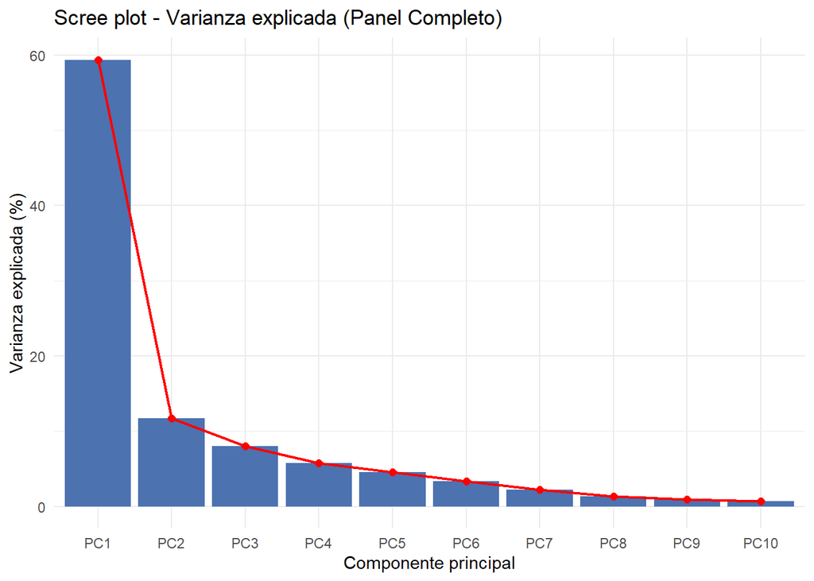

```r
varianza_explicada <- summary(pca_result_panel)$importance[2, ]

tibble(
  PC  = factor(paste0("PC", seq_along(varianza_explicada)),
               levels = paste0("PC", seq_along(varianza_explicada))),
  Var = varianza_explicada * 100
) |>
  slice_head(n = 10) |>
  ggplot(aes(x = PC, y = Var)) +
  geom_col(fill = "#4C72B0") +
  geom_line(aes(group = 1), color = "red", linewidth = 0.8) +
  geom_point(color = "red", size = 2) +
  labs(title = "Scree plot - Varianza explicada (Panel Completo)",
       x = "Componente principal", y = "Varianza explicada (%)") +
  theme_minimal()
```

```r
# Trasponemos: Filas = Indicadores | Columnas = Observaciones (CCAA-Año)
df_pca_t_panel <- t(df_pca_panel)

# Calculamos distancias euclídeas
dist_matrix_panel <- dist(df_pca_t_panel, method = "euclidean")

# Clustering
hclust_panel <- hclust(dist_matrix_panel, method = "ward.D2")

# Dendrograma
plot(hclust_panel,
     main = "Dendrograma de indicadores (2016-2024)",
     xlab = "Indicador", ylab = "Distancia (Similitud de perfil)",
     cex  = 0.7)

# CASO PARA k=3
k_ind <- 3
rect.hclust(hclust_panel, k = k_ind, border = "steelblue")

# Extraemos la lista de indicadores por cluster
clusters_panel <- cutree(hclust_panel, k = k_ind)

df_clusters_panel <- tibble(
  iCode   = names(clusters_panel),
  Cluster = factor(clusters_panel)
) |>
  # Unimos con iMeta para ver a qué dimensión pertenecen originalmente
  left_join(iMeta |> select(iCode, iName, Parent), by = "iCode")

# Resultado ordenado por Cluster
print(df_clusters_panel |> arrange(Cluster), n = 100)
```

```
# A tibble: 52 × 4
   iCode    Cluster iName                                                 Parent
   <chr>    <fct>   <chr>                                                 <chr>
 1 IECO0001 1       "Gasto medio por turista receptor y día"              ECO
 2 IECO0002 1       "Gasto medio por turista receptor"                    ECO
 3 IECO0018 1       "Gasto medio por turista interno y día"               ECO
 4 IECO0036 1       "Precio medio para hotel 5 estrellas con 3 meses de … ECO
 5 IECO0037 1       "Precio medio para hotel 5 estrellas con 1 mes de an… ECO
 6 IECO0038 1       "Precio medio para hotel 5 estrellas con 2 semanas d… ECO
 7 IECO0039 1       "Precio medio para hotel 5 estrellas con 1 semana de… ECO
 8 IECO0040 1       "Precio medio para hotel 4 estrellas con 3 meses de … ECO
 9 IECO0042 1       "Precio medio para hotel 4 estrellas con 2 semanas d… ECO
10 IECO0043 1       "Precio medio para hotel 4 estrellas con 1 semana de… ECO
11 IECO0044 1       "Precio medio para hotel 3 estrellas con 3 meses de … ECO
12 IECO0045 1       "Precio medio para hotel 3 estrellas con 1 mes de an… ECO
```

[output cut: 40 more lines]

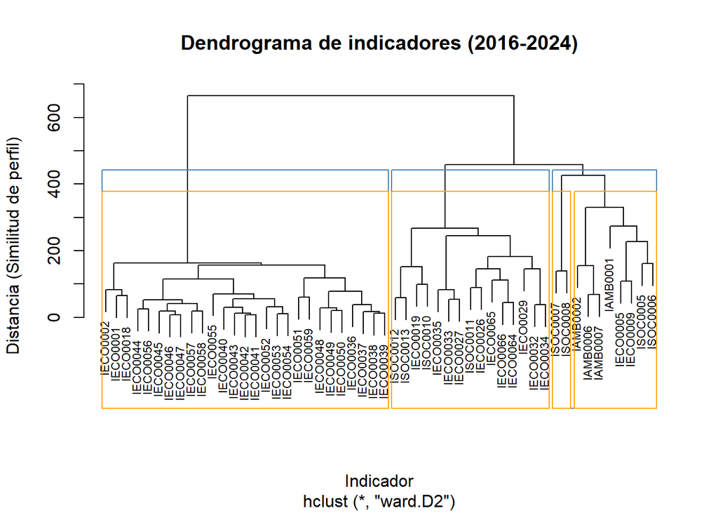

```r
# CASO PARA k=4
k_ind <- 4
rect.hclust(hclust_panel, k = k_ind, border = "orange")
```

```r
# Extraemos la lista de indicadores por cluster
clusters_panel <- cutree(hclust_panel, k = k_ind)

df_clusters_panel <- tibble(
  iCode   = names(clusters_panel),
  Cluster = factor(clusters_panel)
) |>
  # Unimos con iMeta para ver a qué dimensión pertenecen originalmente
  left_join(iMeta |> select(iCode, iName, Parent), by = "iCode")

# Resultado ordenado por Cluster
print(df_clusters_panel |> arrange(Cluster), n = 100)
```

```
# A tibble: 52 × 4
   iCode    Cluster iName                                                 Parent
   <chr>    <fct>   <chr>                                                 <chr>
 1 IECO0001 1       "Gasto medio por turista receptor y día"              ECO
 2 IECO0002 1       "Gasto medio por turista receptor"                    ECO
 3 IECO0018 1       "Gasto medio por turista interno y día"               ECO
 4 IECO0036 1       "Precio medio para hotel 5 estrellas con 3 meses de … ECO
 5 IECO0037 1       "Precio medio para hotel 5 estrellas con 1 mes de an… ECO
 6 IECO0038 1       "Precio medio para hotel 5 estrellas con 2 semanas d… ECO
 7 IECO0039 1       "Precio medio para hotel 5 estrellas con 1 semana de… ECO
 8 IECO0040 1       "Precio medio para hotel 4 estrellas con 3 meses de … ECO
 9 IECO0042 1       "Precio medio para hotel 4 estrellas con 2 semanas d… ECO
10 IECO0043 1       "Precio medio para hotel 4 estrellas con 1 semana de… ECO
11 IECO0044 1       "Precio medio para hotel 3 estrellas con 3 meses de … ECO
12 IECO0045 1       "Precio medio para hotel 3 estrellas con 1 mes de an… ECO
```

[output cut: 40 more lines]

Analizando Scree-plot: Nos fijamos en la línea roja. Usando el método del codo, la pendiente de la curva comienza a aplanarse a partir del la 3ra o 4ta componente. Probamos clustering para k=3 y para k=4.

## PCA por niveles

Ahora hacemos el PCA por niveles. Los pesos que obtengamos para cada indicador los guardamos en los metadatos (en iMeta$Weights).

```r
dimensiones <- iMeta |>
  filter(Level == 1) |>
  pull(Parent) |>
  unique()

pesos_pca_L1 <- map_df(dimensiones, function(dim) {

  # qué indicadores queremos
  inds_dim <- iMeta |>
    filter(Level == 1, Parent == dim) |>
    pull(iCode)

  df_dim <- df_norm_todos |>
    select(any_of(inds_dim)) |>
    select(where(\(x) var(x, na.rm = TRUE) > 1e-10))

  if (ncol(df_dim) < 2) return(NULL)

  pca_dim <- prcomp(df_dim, center = TRUE, scale. = TRUE)

  # Usamos solo PC1: los loadings absolutos del primer componente
  loadings_pc1 <- abs(pca_dim$rotation[, 1])
  pesos_norm   <- loadings_pc1 / sum(loadings_pc1)

  # Diagnóstico: varianza explicada por PC1
  var_pc1 <- pca_dim$sdev[1]^2 / sum(pca_dim$sdev^2)
  cat("Dimensión ", dim, " - Varianza explicada PC1: ", round(var_pc1 * 100, 1), "% \n")

  tibble(
    iCode      = colnames(df_dim),
    Parent     = dim,
    Weight_PCA = round(pesos_norm, 4)
  )
})
```

```
Dimensión  ECO  - Varianza explicada PC1:  72.3 %
Dimensión  ENV  - Varianza explicada PC1:  64.8 %
Dimensión  SOC  - Varianza explicada PC1:  45 %
```

```r
print(pesos_pca_L1 |> arrange(Parent, desc(Weight_PCA)), n = 60)
```

```
# A tibble: 52 × 3
   iCode    Parent Weight_PCA
   <chr>    <chr>       <dbl>
 1 IECO0054 ECO        0.0295
 2 IECO0053 ECO        0.0294
 3 IECO0045 ECO        0.0293
 4 IECO0046 ECO        0.0293
 5 IECO0047 ECO        0.0292
 6 IECO0057 ECO        0.0292
 7 IECO0042 ECO        0.0291
 8 IECO0052 ECO        0.029
 9 IECO0041 ECO        0.029
10 IECO0038 ECO        0.0289
11 IECO0058 ECO        0.0289
12 IECO0039 ECO        0.0288
```

[output cut: 40 more lines]

```r
# Score de cada dimensión = media ponderada de sus indicadores con pesos PCA L1
df_scores_dim <- map_df(dimensiones, function(dim) {

  inds_dim <- pesos_pca_L1 |>
    filter(Parent == dim) |>
    pull(iCode)

  pesos_dim <- pesos_pca_L1 |>
    filter(Parent == dim) |>
    pull(Weight_PCA)

  df_dim <- df_norm_todos |>
    select(any_of(inds_dim))

  score <- as.vector(as.matrix(df_dim) %*% pesos_dim)

  tibble(dimension = dim, score = score, obs = seq_len(nrow(df_dim)))
}) |>
  pivot_wider(names_from = dimension, values_from = score, id_cols = obs) |>
  select(-obs)

# PCA sobre los scores de las 3 dimensiones - solo PC1
pca_L2 <- prcomp(df_scores_dim, center = TRUE, scale. = TRUE)

var_pc1_L2 <- pca_L2$sdev[1]^2 / sum(pca_L2$sdev^2)
cat("Varianza explicada PC1 nivel dimensiones: ", round(var_pc1_L2 * 100, 1), "% \n")
```

```
Varianza explicada PC1 nivel dimensiones:  54.4 %
```

```r
loadings_L2   <- abs(pca_L2$rotation[, 1])
pesos_L2_norm <- loadings_L2 / sum(loadings_L2)

df_pesos_L2 <- tibble(
  iCode      = dimensiones,
  Weight_PCA = round(pesos_L2_norm, 4)
)

print(df_pesos_L2)
```

```
# A tibble: 3 × 2
  iCode Weight_PCA
  <chr>      <dbl>
1 ECO        0.296
2 ENV        0.314
3 SOC        0.390
```

Actualizamos los pesos como hemos dicho antes.

```r
# Nivel 1: Pesos PCA para cada indicador individual dentro de su dimensión
# Nivel 2: Pesos PCA para las 3 dimensiones (ENV, ECO, SOC) del índice final

# Unimos los pesos de Nivel 1 (indicadores) y Nivel 2 (dimensiones)
iMeta_PCA <- iMeta |>
  # Pesos PCA para indicadores individuales (Nivel 1)
  left_join(
    pesos_pca_L1|> select(iCode, Weight_PCA),
    by = "iCode"
  ) |>
  rename(Weight_PCA_L1 = Weight_PCA) |>

  # Pesos PCA para las 3 dimensiones (Nivel 2)
  left_join(
    df_pesos_L2|> select(iCode, Weight_PCA),
    by = "iCode"
  ) |>
  rename(Weight_PCA_L2 = Weight_PCA) |>

  # Asignamos los pesos definitivos
  mutate(
    Weight = case_when(
      Level == 1 & !is.na(Weight_PCA_L1) ~ Weight_PCA_L1,  # Pesos PCA para indicadores
      Level == 2 & !is.na(Weight_PCA_L2) ~ Weight_PCA_L2,  # Pesos PCA para dimensiones
      TRUE ~ Weight                                         # Mantener peso original si no hay PCA
    )
  ) |>

  # Limpiamos columnas temporales
  select(-Weight_PCA_L1, -Weight_PCA_L2)


# Verificamos pesos que han salido de las dimensiones

cat(" PESOS DE LAS DIMENSIONES (Nivel 2) \n")
```

```
 PESOS DE LAS DIMENSIONES (Nivel 2)
```

```r
print(iMeta_PCA |>
        filter(Level == 2) |>
        select(iCode, Weight) |>
        arrange(desc(Weight)))
```

```
# A tibble: 3 × 2
  iCode Weight
  <chr>  <dbl>
1 SOC    0.390
2 ENV    0.314
3 ECO    0.296
```

```r
cat("\n RESUMEN DE PESOS \n")
```

```
 RESUMEN DE PESOS
```

```r
cat("Suma de pesos dimensiones (debería ser 1): ",
        round(sum(iMeta_PCA |> filter(Level == 2) |> pull(Weight)), 4), "\n")
```

```
Suma de pesos dimensiones (debería ser 1):  1
```

```r
# Reconstruimos el purse con los pesos obtenidos y VOLVEMOS A PONER LOS DATOS IMPUTADOS CON MICE EN iDATA !!
purse_PCA <- new_coin(
  iData    = iData_imputed_mice,
  iMeta    = iMeta_PCA,
  split_to = "all",
  quietly  = TRUE
)

# Marcamos datos como ya imputados en cada coin del purse_PCA (igual que antes)
for(i in seq_along(purse_PCA$coin)){
  purse_PCA$coin[[i]]$Data$Imputed <- purse_PCA$coin[[i]]$Data$Raw
}

# Continuamos como antes con Treat() y con Normalise()
purse_PCA <- Treat(
  purse_PCA,
  dset = "Imputed",
  f_t = "winsorise",
  f_t_para = list(
    winmax = 5,
    skew_thresh = 2,
    kurt_thresh = 3.5,
    force_win = TRUE
  ),
  disable = FALSE
)

purse_PCA <- Normalise(
  purse_PCA,
  dset         = "Treated",
  normalise_by = "all",
  f_n          = "n_minmax",
  f_n_para     = list(l_u = c(1, 100))
)

# Verificamos finalmente

dset_norm <- get_dset(purse_PCA, dset = "Normalised")

cat("\n ESTADÍSTICAS DEL DATASET NORMALIZADO \n")
```

```
 ESTADÍSTICAS DEL DATASET NORMALIZADO
```

```r
cat("Mínimo: ", round(min(dset_norm[, -c(1, 2)], na.rm = TRUE), 2), "\n")
```

[output not shown]

```r
cat("Máximo: ", round(max(dset_norm[, -c(1, 2)], na.rm = TRUE), 2), "\n")
```

```
Máximo:  100
```

```r
cat("NAs totales: ", sum(is.na(dset_norm[, -c(1, 2)])), "\n")
```

```
NAs totales:  4
```

```r
# Guardamos el purse procesado para usarlo después
print(purse_PCA)
```

```
-----------------------------
A purse with... 6 coins
-----------------------------

 Time n_Units n_Inds n_dsets
 2019       4     52       4
 2020       4     52       4
 2021       4     52       4
 2022       4     52       4
 2023       4     52       4
 2024       4     52       4

-----------------------------------
Sample from first coin (2019):
-----------------------------------

Input:
  Units: 4 (ES-AN, ES-CT, ES-MD, ...)
  Indicators: 52 (IECO0001, IECO0002, IECO0005, ...)
  Denominators: 0 ()
  Groups: 0 (none)

Structure:
  Level 1 : 52 indicators (IECO0001, IECO0002, IECO0005, ...)
  Level 2 : 3 groups (ECO, ENV, SOC)
  Level 3 : 1 groups (TotalIndex)

Data sets:
  Raw (4 units)
  Imputed (4 units)
  Treated (4 units)
  Normalised (4 units)
```

## CASO 5: PCA/FA manual OCDE

```r
# Función que calcula pesos OCDE para una dimensión (ECO, SOC o ENV)
calcular_pesos_ocde <- function(dim, df_datos, iMeta_ref) {

  # Seleccionamos indicadores que pertenecen a la dimensión
  inds_dim <- iMeta_ref |> filter(Level == 1, Parent == dim) |> pull(iCode)
  df_dim <- df_datos |> select(any_of(inds_dim))

  # Eliminamos variables con varianza 0 (necesario para el PCA)
  df_dim <- df_dim |> select(where(\(x) var(x, na.rm = TRUE) > 1e-10))

  # Determinamos cuántos componentes retener (Criterio OCDE: Eigenvalue > 1)
  pca_previo <- prcomp(df_dim, center = TRUE, scale. = TRUE)
  n_factores <- sum(pca_previo$sdev^2 > 1)

  # Si solo sale 1 factor, no se puede rotar, usamos el PCA simple (los pesos
  # se obtienen directamente de las cargas del primer componente)
  if (n_factores < 2) {
    loadings_pc1 <- abs(pca_previo$rotation[, 1]) # importancia de cada indicador
    pesos <- loadings_pc1^2 / sum(loadings_pc1^2) # OCDE usa cuadrados de cargas
    return(tibble(iCode = names(pesos), Weight_OCDE = pesos, Factor = "F1", Var_Factor = 1))
  }

  # Rotación Varimax
  # Usamos la función principal del paquete psych
  rotacion <- psych::principal(df_dim, nfactors = n_factores, rotate = "varimax")

  # Asignamos cada indicador al factor donde más carga tiene
  loadings_mat <- as.data.frame(unclass(rotacion$loadings))
  cargas_maximas <- loadings_mat |>
    mutate(iCode = rownames(loadings_mat),
           Factor_Asignado = colnames(loadings_mat)[apply(loadings_mat, 1, which.max)])

  # Calculamos pesos intermedios y finales
  pesos_finales <- cargas_maximas |>
    pivot_longer(cols = starts_with("RC"), names_to = "Factor", values_to = "Carga") |>
    filter(Factor == Factor_Asignado) |>
    group_by(Factor) |>
    mutate(
      # Peso relativo dentro del grupo (indicadores más importantes pesan más)
      Weight_in_Factor = Carga^2 / sum(Carga^2)) |>
    ungroup()

 # Calculamos la importancia de cada factor (varianza explicada)
  var_explicada <- rotacion$Vaccounted["Proportion Var", ]
  var_relativa <- var_explicada / sum(var_explicada)

# Peso final = peso dentro del factor x importancia del factor
  pesos_finales <- pesos_finales |>
    mutate(Var_Factor = as.numeric(var_relativa[Factor]),
           Weight_OCDE = Weight_in_Factor * Var_Factor)

# Devolvemos pesos finales por indicador
  return(pesos_finales |> select(iCode, Weight_OCDE, Factor, Var_Factor))
}

# Aplicamos la función a las 3 dimensiones
pesos_ocde_L1 <- map_df(c("ECO", "SOC", "ENV"), \(d) {
  res <- calcular_pesos_ocde(d, df_norm_todos, iMeta)
  res$Dimension <- d
  res
})

# Mostramos resultados ordenados
print(pesos_ocde_L1 |> arrange(Dimension, Factor, desc(Weight_OCDE)), n = 39)
```

```
# A tibble: 52 × 5
   iCode    Weight_OCDE Factor Var_Factor Dimension
   <chr>          <dbl> <chr>       <dbl> <chr>
 1 IECO0040     0.0271  RC1         0.581 ECO
 2 IECO0043     0.0267  RC1         0.581 ECO
 3 IECO0041     0.0263  RC1         0.581 ECO
 4 IECO0042     0.0263  RC1         0.581 ECO
 5 IECO0052     0.0250  RC1         0.581 ECO
 6 IECO0056     0.0248  RC1         0.581 ECO
 7 IECO0057     0.0237  RC1         0.581 ECO
 8 IECO0037     0.0234  RC1         0.581 ECO
 9 IECO0054     0.0233  RC1         0.581 ECO
10 IECO0053     0.0232  RC1         0.581 ECO
11 IECO0038     0.0232  RC1         0.581 ECO
12 IECO0039     0.0231  RC1         0.581 ECO
```

[output cut: 28 more lines]

```r
# La suma de los pesos debería darnos 1
cat("Suma total de pesos OCDE:", sum(pesos_ocde_L1$Weight_OCDE), "\n")
```

```
Suma total de pesos OCDE: 2.904306
```

```r
pesos_ocde_L1 |> group_by(Dimension) |>
  summarise(suma = sum(Weight_OCDE))
```

```
# A tibble: 3 × 2
  Dimension  suma
  <chr>     <dbl>
1 ECO       0.904
2 ENV       1
3 SOC       1
```

Quiero ver los nombres de los indicadores que pertenecen a cada factor:

```r
# Creamos la tabla descriptiva de indicadores por factor
tabla_factores_detalle <- pesos_ocde_L1 |>
  # Unimos con iMeta para traer el nombre del indicador (iName)
  left_join(
    iMeta |> select(iCode, iName),
    by = "iCode"
  ) |>
  # Seleccionamos y reordenamos las columnas
  select(Dimension, Factor, iCode, iName, Weight_OCDE) |>
  # Ordenamos
  arrange(Dimension, Factor, desc(Weight_OCDE))

# Imprimimos la tabla
tabla_factores_detalle |>
  knitr::kable(
    caption = "Composición de Factores (PCA con Rotación Varimax) - OCDE",
    digits = 4,
    col.names = c("Dimensión", "Factor", "Código", "Nombre Indicador", "Peso Final"),
    format = "html"
  )
```

Composición de Factores (PCA con Rotación Varimax) - OCDE

| Dimensión | Factor | Código | Nombre Indicador | Peso Final |
| --- | --- | --- | --- | --- |
| ECO | RC1 | IECO0040 | Precio medio para hotel 4 estrellas con 3 meses de antelación con fecha de check-in entre semana | 0.0271 |
| ECO | RC1 | IECO0043 | Precio medio para hotel 4 estrellas con 1 semana de antelación con fecha de check-in entre semana | 0.0267 |
| ECO | RC1 | IECO0041 | Precio medio para hotel 4 estrellas con 1 mes de antelación con fecha de check-in entre semana | 0.0263 |
| ECO | RC1 | IECO0042 | Precio medio para hotel 4 estrellas con 2 semanas de antelación con fecha de check-in entre semana | 0.0263 |
| ECO | RC1 | IECO0052 | Precio medio para hotel 4 estrellas con 3 meses de antelación con fecha de check-in en fin de semana | 0.0250 |
| ECO | RC1 | IECO0056 | Precio medio para hotel 3 estrellas con 3 meses de antelación con fecha de check-in en fin de semana | 0.0248 |
| ECO | RC1 | IECO0057 | Precio medio para hotel 3 estrellas con 1 mes de antelación con fecha de check-in en fin de semana | 0.0237 |
| ECO | RC1 | IECO0037 | Precio medio para hotel 5 estrellas con 1 mes de antelación con fecha de check-in entre semana | 0.0234 |
| ECO | RC1 | IECO0054 | Precio medio para hotel 4 estrellas con 2 semanas de antelación con fecha de check-in en fin de semana | 0.0233 |
| ECO | RC1 | IECO0053 | Precio medio para hotel 4 estrellas con 1 mes de antelación con fecha de check-in en fin de semana | 0.0232 |
| ECO | RC1 | IECO0038 | Precio medio para hotel 5 estrellas con 2 semanas de antelación con fecha de check-in entre semana | 0.0232 |
| ECO | RC1 | IECO0039 | Precio medio para hotel 5 estrellas con 1 semana de antelación con fecha de check-in entre semana | 0.0231 |
| ECO | RC1 | IECO0036 | Precio medio para hotel 5 estrellas con 3 meses de antelación con fecha de check-in entre semana | 0.0230 |
| ECO | RC1 | IECO0044 | Precio medio para hotel 3 estrellas con 3 meses de antelación con fecha de check-in entre semana | 0.0226 |
| ECO | RC1 | IECO0058 | Precio medio para hotel 3 estrellas con 2 semanas de antelación con fecha de check-in en fin de semana | 0.0225 |
| ECO | RC1 | IECO0045 | Precio medio para hotel 3 estrellas con 1 mes de antelación con fecha de check-in entre semana | 0.0224 |
| ECO | RC1 | IECO0047 | Precio medio para hotel 3 estrellas con 1 semana de antelación con fecha de check-in entre semana | 0.0220 |
| ECO | RC1 | IECO0046 | Precio medio para hotel 3 estrellas con 2 semanas de antelación con fecha de check-in entre semana | 0.0218 |
| ECO | RC1 | IECO0002 | Gasto medio por turista receptor | 0.0208 |
| ECO | RC1 | IECO0055 | Precio medio para hotel 4 estrellas con 1 semana de antelación con fecha de check-in en fin de semana | 0.0194 |
| ECO | RC1 | IECO0018 | Gasto medio por turista interno y día | 0.0190 |
| ECO | RC1 | IECO0050 | Precio medio para hotel 5 estrellas con 2 semanas de antelación con fecha de check-in en fin de semana | 0.0176 |
| ECO | RC1 | IECO0049 | Precio medio para hotel 5 estrellas con 1 mes de antelación con fecha de check-in en fin de semana | 0.0167 |
| ECO | RC1 | IECO0048 | Precio medio para hotel 5 estrellas con 3 meses de antelación con fecha de check-in en fin de semana | 0.0165 |
| ECO | RC1 | IECO0001 | Gasto medio por turista receptor y día | 0.0146 |
| ECO | RC1 | IECO0019 | Gasto medio por turista interno | 0.0135 |
| ECO | RC1 | IECO0059 | Precio medio para hotel 3 estrellas con 1 semana de antelación con fecha de check-in en fin de semana | 0.0120 |
| ECO | RC2 | IECO0035 | Variación interanual ingresos por habitación disponible (REVPAR) | 0.0395 |
| ECO | RC2 | IECO0033 | Variación interanual tarifa media diaria (ADR) | 0.0380 |
| ECO | RC2 | IECO0027 | Variacíon anual del Índice de Precios Hoteleros (IPH) | 0.0335 |
| ECO | RC2 | IECO0064 | Variación mensual del IPC de turismo y hostelería | 0.0256 |
| ECO | RC4 | IECO0026 | Índice de Precios Hoteleros (IPH) | 0.0392 |
| ECO | RC4 | IECO0066 | Variación acumulada del IPC de turismo y hostelería | 0.0295 |
| ECO | RC4 | IECO0029 | Índice de precios de turismo y hostelería | 0.0277 |
| ECO | RC4 | IECO0065 | Variación interanual del IPC de turismo y hostelería | 0.0265 |
| ECO | RC4 | IECO0034 | Ingresos medios por habitación disponible (REVPAR) | 0.0231 |
| ECO | RC4 | IECO0032 | Tarifa media diaria (ADR) | 0.0229 |
| ECO | RC4 | IECO0051 | Precio medio para hotel 5 estrellas con 1 semana de antelación con fecha de check-in en fin de semana | 0.0153 |
| ECO | RC4 | IECO0005 | Estancia media por turista receptor | 0.0030 |
| ECO | RC4 | IECO0009 | Estancia media por turista interno | 0.0001 |
| ENV | F1 | IAMB0006 | Porcentaje de turistas receptores que llegan por avión | 0.3088 |
| ENV | F1 | IAMB0007 | Porcentaje de turistas receptores que llegan por mar y tierra | 0.3021 |
| ENV | F1 | IAMB0002 | Porcentaje de medios de transporte menos contaminante utilizados por los turistas receptores | 0.2591 |
| ENV | F1 | IAMB0001 | Gasto energético menos contaminante | 0.1300 |
| SOC | RC1 | ISOC0005 | Índice de Percepción Turística Global | 0.1382 |
| SOC | RC1 | ISOC0013 | Índice de satisfacción con los alojamientos hoteleros | 0.0940 |
| SOC | RC1 | ISOC0012 | Índice de satisfacción con los hoteles 3 estrellas | 0.0803 |
| SOC | RC1 | ISOC0010 | Índice de satisfacción con los hoteles 5 estrellas | 0.0781 |
| SOC | RC1 | ISOC0006 | Índice Satisfacción Productos Turísticos | 0.0003 |
| SOC | RC2 | ISOC0007 | Índice de Percepción de Seguridad | 0.1506 |
| SOC | RC2 | ISOC0008 | Índice de Percepción Climática | 0.1096 |
| SOC | RC3 | ISOC0011 | Índice de satisfacción con los hoteles 4 estrellas | 0.3489 |

```r
library(openxlsx)
library(dplyr)
library(tidyr)
library(lubridate)

# 1. Definimos la lista maestra de todos los indicadores que DEBERÍAN estar
# Usamos los indicadores de iMeta que no han sido eliminados
todos_los_indicadores <- iMeta$iCode[!(iMeta$iCode %in% indicadores_eliminar) &
  !(iMeta$iCode %in% c("ECO", "ENV", "SOC", "TotalIndex")) ]

# 2. Definimos la lista maestra de todas las regiones (uCode)
todas_las_regiones <- unique(indicadores_calculados_final$geo_id)

wb <- createWorkbook()

for(anio in sort(anios)){

  tabla_nas_anio <- indicadores_calculados_final |>
    mutate(Time = year(as.Date(date))) |>
    filter(Time == anio, !indicator_id %in% indicadores_eliminar) |>
    mutate(es_na = if_else(is.na(value), 1, 0)) |>
    select(uCode = geo_id, indicator_id, es_na) |>
    # --- PASO CLAVE: FORZAR ESTRUCTURA COMPLETA ---
    # Esto asegura que todas las combinaciones Indicador-Región existan
    complete(indicator_id = todos_los_indicadores, uCode = todas_las_regiones) |>
    # ----------------------------------------------
    pivot_wider(names_from = uCode,
                values_from = es_na) |>
    # Ordenar por ID de indicador para que todos los años sean idénticos visualmente
    arrange(indicator_id)

  nombre_hoja <- as.character(anio)
  addWorksheet(wb, nombre_hoja)
  writeData(wb, nombre_hoja, tabla_nas_anio)

  addStyle(wb, nombre_hoja, style = createStyle(textDecoration = "bold"),
           rows = 1, cols = 1:ncol(tabla_nas_anio))
}

saveWorkbook(wb, "Analisis_NAs_4CCAA.xlsx", overwrite = TRUE)

cat("Excel generado con estructura fija de 52 indicadores para todos los años.")
```

```
Excel generado con estructura fija de 52 indicadores para todos los años.
```

# Intento análisis de incertidumbre y sensibilidad

No tenemos el aggregated. Todavía no se puede.

```r
# 1. Definimos la lista de años desde el purse
anios_disponibles <- sort(unique(purse$Time))

# 2. Especificaciones de variabilidad (+/- 20% en pesos)
sa_specs <- list(
  Weights = list(
    Address = "$Log$Aggregate$w",
    Distribution = "u",
    DistProp = c(0.8, 1.2),
    Type = "p"
  )
)

# 3. Bucle para procesar cada año
for (a in anios_disponibles) {

  cat("\n\n## Análisis de Sensibilidad: Año", a, "\n")

  # Extraemos el coin del purse de forma segura
  coin_anio <- tryCatch({
    get_coin(purse, dset = "Aggregated", TimeIdx = a)
  }, error = function(e) NULL)

  if (!is.null(coin_anio)) {

    # Ejecutamos Monte Carlo (N=500 para mayor profundidad)
    res_sa <- get_sensitivity(
      coin = coin_anio,
      SA_specs = sa_specs,
      N = 500,
      SA_type = "SA",
      dset = "Aggregated",
      iCode = "TotalIndex",
      Nboot = 100,
      quietly = TRUE,
      check_addresses = FALSE
    )

    # Generamos el gráfico de Sobol (Sensibilidad)
    p <- plot_sensitivity(res_sa, iCode = "TotalIndex") +
      labs(title = paste("Sensibilidad de Pesos - Año", a),
           subtitle = "Simulación de Monte Carlo (N=500)")

    print(p)

    cat("\n\n*Interpretación:* Este gráfico muestra qué indicadores influyen más en el ranking final de", a, ". Una barra alta indica que el índice es muy sensible a ese dato.*\n")

  } else {
    cat("\n\nNo se pudo extraer el coin para el año", a, "\n")
  }
}
```

```
## Análisis de Sensibilidad: Año 2019


No se pudo extraer el coin para el año 2019


## Análisis de Sensibilidad: Año 2020


No se pudo extraer el coin para el año 2020


## Análisis de Sensibilidad: Año 2021


No se pudo extraer el coin para el año 2021


## Análisis de Sensibilidad: Año 2022


No se pudo extraer el coin para el año 2022


## Análisis de Sensibilidad: Año 2023


No se pudo extraer el coin para el año 2023


## Análisis de Sensibilidad: Año 2024


No se pudo extraer el coin para el año 2024
```